# **Building a Music Recommendation Engine: A Data Science Pipeline**

**Authors:** Anoushka Anand (122018419), Himisha Gupta (122131040), FNU Hardik (122279933)

1. Introduction
2. Data Collection and Curation
3. Exploratory Data Analysis
4. Feature Engineering
5. Building Recommendation Models
6. Evaluation and Results
7. Insights and Conclusions
8. References and Resources

# **1. Introduction**

## **The Challenge of Music Discovery**

Imagine standing in a record store with 100 million songs. How would you find music you'll love?  
This is the daily challenge faced by modern streaming platforms like Spotify, Apple Music, and YouTube Music.

As of 2025, Spotify hosts **over 100 million tracks**, with tens of thousands more added every day. Without effective recommendation systems, this abundance becomes overwhelming, a phenomenon known as the *paradox of choice*.

Music recommendation systems solve this problem by acting as intelligent curators, analyzing patterns in audio features, user behavior, and social signals to connect listeners with songs they’ll enjoy. According to industry research, **over 30% of total streaming time** on major platforms is driven by algorithmic recommendations, making these systems essential to both user experience and business success.

## **Why Music Recommendation Is Unique**

Unlike recommending movies or books, music recommendation presents several unique challenges:

- **Short consumption time:** A 3-minute song provides far less feedback signal than a 2-hour movie.
- **Context sensitivity:** Users want different music when working out, studying, relaxing, or commuting.
- **Mood dependency:** Preferences fluctuate with emotional state.
- **High replay value:** People may listen to the same track hundreds of times.
- **Subjective audio qualities:** Musical taste is deeply personal and difficult to quantify.

These challenges make music recommendation an ideal case study for understanding the complexities of intelligent information retrieval systems.

## **Data Science Pipeline Overview**

This tutorial walks through the complete data science workflow:

**Raw Data → Cleaning → Exploratory Data Analysis (EDA) → Feature Engineering → Modeling → Evaluation → Insights**

At each stage, we apply rigorous analytical methods while maintaining a focus on practical, real-world applicability.  
The goal is not only to build models that run in a notebook, but also to understand principles that scale to production systems serving millions of users.

## **Learning Objectives**

By the end of this tutorial, you will be able to:

- Clean and preprocess large-scale music metadata
- Conduct meaningful exploratory analysis on high-dimensional audio data
- Implement and compare multiple recommendation algorithms
- Evaluate recommendation quality using appropriate metrics
- Understand trade-offs between accuracy, diversity, and scalability
- Apply these techniques to other recommendation domains

## **About the Dataset**

We use **Spotify’s 30,000 Songs Dataset** from Kaggle, which contains rich metadata for approximately 30,000 tracks.  
Each track includes:

### **Audio Features (9 total)**

- Danceability
- Energy
- Loudness
- Speechiness
- Acousticness
- Instrumentalness
- Liveness
- Valence
- Tempo

### **Metadata**

- Track name
- Artist
- Album
- Popularity score

### **Genre Labels**

- Playlist genre
- Playlist subgenre

These features come from Spotify’s Audio Analysis API, which uses machine learning models to extract musical characteristics from raw audio.  
For example:

- **Valence** measures the musical positiveness of a track (happy vs. sad).
- **Danceability** describes how suitable a track is for dancing, based on rhythm stability and beat strength.

### **Dataset Source**

- *30000 Spotify Songs* on Kaggle:  
  https://www.kaggle.com/datasets/joebeachcapital/30000-spotify-songs
- *Spotify Web API Documentation: Audio Features Reference*:  
  https://developer.spotify.com/documentation/web-api/reference/get-audio-features

# **2. Data Collection and Curation**

### 2.1 Environment Setup

To ensure a smooth workflow, we begin by importing the core Python libraries used throughout this tutorial.  
These include tools for:

- Data manipulation (`pandas`, `numpy`)
- Visualization (`matplotlib`, `seaborn`, `plotly`)
- Machine learning and preprocessing (`scikit-learn`)
- Similarity computation (`cosine_similarity`)

A clean and consistent environment helps avoid dependency issues and ensures that results are reproducible across systems.

```python
import pandas as pd
import numpy as np
import warnings
import shutil
import os
warnings.filterwarnings('ignore')

import matplotlib.pyplot as plt
import seaborn as sns
import plotly.express as px
import plotly.graph_objects as go
from IPython.display import display, Markdown

from sklearn.preprocessing import StandardScaler, MinMaxScaler
from sklearn.decomposition import PCA
from sklearn.cluster import KMeans
from sklearn.metrics.pairwise import cosine_similarity, euclidean_distances
from sklearn.model_selection import train_test_split
from sklearn.metrics import mean_squared_error, mean_absolute_error

from scipy.sparse import csr_matrix
from scipy.spatial.distance import cdist

plt.style.use('seaborn-v0_8-darkgrid')
sns.set_palette("husl")

pd.set_option('display.max_columns', None)
pd.set_option('display.width', None)
pd.set_option('display.max_colwidth', 50)

print("Environment setup complete!")
```

```
Environment setup complete!
```

### 2.2 Loading the Dataset

We use the **30,000 Spotify Songs Dataset** from Kaggle, which must be downloaded and placed in the working directory.  
After loading the dataset into a pandas DataFrame, we perform an initial inspection to understand its structure.

Key questions at this stage include:

- Do the column names clearly represent the underlying attributes?
- Are numerical features stored in the correct data types (float/int)?
- Are there any obvious issues such as null values or unexpected categories?
- How many songs and features does the dataset contain?

This initial overview provides the foundation for deeper quality assessment and cleaning steps performed in the next sections.

```python
!pip install kaggle -q
```

```python
# download the dataset
!kaggle datasets download -d joebeachcapital/30000-spotify-songs
```

```
Dataset URL: https://www.kaggle.com/datasets/joebeachcapital/30000-spotify-songs
License(s): DbCL-1.0
Downloading 30000-spotify-songs.zip to /Users/himishagupta/DS_Project_2
```

```python
# if not unzipped, unzip the dataset

if not os.path.isfile("data/spotify_songs.csv"):
    os.mkdir("data/")
    shutil.unpack_archive("30000-spotify-songs.zip", "data")
```

```python
df = pd.read_csv('data/spotify_songs.csv')
display(Markdown("#### Dataset Overview"))
display(Markdown(f"**Shape:** {df.shape[0]} rows × {df.shape[1]} columns"))
```

Dataset Overview

**Shape:** 32833 rows × 23 columns

#### First Few Rows

```python
display(df.head())
```

|  | track_id | track_name | track_artist | track_popularity | track_album_id | track_album_name | track_album_release_date | playlist_name | playlist_id | playlist_genre | playlist_subgenre | danceability | energy | key | loudness | mode | speechiness | acousticness | instrumentalness | liveness | valence | tempo | duration_ms |
| --- | --- | --- | --- | --- | --- | --- | --- | --- | --- | --- | --- | --- | --- | --- | --- | --- | --- | --- | --- | --- | --- | --- | --- |
| 0 | 6f807x0ima9a1j3VPbc7VN | I Don't Care (with Justin Bieber) - Loud Luxur... | Ed Sheeran | 66 | 2oCs0DGTsRO98Gh5ZSl2Cx | I Don't Care (with Justin Bieber) [Loud Luxury... | 2019-06-14 | Pop Remix | 37i9dQZF1DXcZDD7cfEKhW | pop | dance pop | 0.748 | 0.916 | 6 | -2.634 | 1 | 0.0583 | 0.1020 | 0.000000 | 0.0653 | 0.518 | 122.036 | 194754 |
| 1 | 0r7CVbZTWZgbTCYdfa2P31 | Memories - Dillon Francis Remix | Maroon 5 | 67 | 63rPSO264uRjW1X5E6cWv6 | Memories (Dillon Francis Remix) | 2019-12-13 | Pop Remix | 37i9dQZF1DXcZDD7cfEKhW | pop | dance pop | 0.726 | 0.815 | 11 | -4.969 | 1 | 0.0373 | 0.0724 | 0.004210 | 0.3570 | 0.693 | 99.972 | 162600 |
| 2 | 1z1Hg7Vb0AhHDiEmnDE79l | All the Time - Don Diablo Remix | Zara Larsson | 70 | 1HoSmj2eLcsrR0vE9gThr4 | All the Time (Don Diablo Remix) | 2019-07-05 | Pop Remix | 37i9dQZF1DXcZDD7cfEKhW | pop | dance pop | 0.675 | 0.931 | 1 | -3.432 | 0 | 0.0742 | 0.0794 | 0.000023 | 0.1100 | 0.613 | 124.008 | 176616 |
| 3 | 75FpbthrwQmzHlBJLuGdC7 | Call You Mine - Keanu Silva Remix | The Chainsmokers | 60 | 1nqYsOef1yKKuGOVchbsk6 | Call You Mine - The Remixes | 2019-07-19 | Pop Remix | 37i9dQZF1DXcZDD7cfEKhW | pop | dance pop | 0.718 | 0.930 | 7 | -3.778 | 1 | 0.1020 | 0.0287 | 0.000009 | 0.2040 | 0.277 | 121.956 | 169093 |
| 4 | 1e8PAfcKUYoKkxPhrHqw4x | Someone You Loved - Future Humans Remix | Lewis Capaldi | 69 | 7m7vv9wlQ4i0LFuJiE2zsQ | Someone You Loved (Future Humans Remix) | 2019-03-05 | Pop Remix | 37i9dQZF1DXcZDD7cfEKhW | pop | dance pop | 0.650 | 0.833 | 1 | -4.672 | 1 | 0.0359 | 0.0803 | 0.000000 | 0.0833 | 0.725 | 123.976 | 189052 |

#### Data Types and Missing Values

```python
info_df = pd.DataFrame({
    'Column': df.columns,
    'Data Type': df.dtypes.astype(str).values,
    'Missing Values': df.isnull().sum().values,
    'Missing %': (df.isnull().sum() / len(df) * 100).round(2).values
})

display(info_df.style.set_table_attributes('style="width:60%"'))
```

|  | Column | Data Type | Missing Values | Missing % |
| --- | --- | --- | --- | --- |
| 0 | track_id | object | 0 | 0.000000 |
| 1 | track_name | object | 5 | 0.020000 |
| 2 | track_artist | object | 5 | 0.020000 |
| 3 | track_popularity | int64 | 0 | 0.000000 |
| 4 | track_album_id | object | 0 | 0.000000 |
| 5 | track_album_name | object | 5 | 0.020000 |
| 6 | track_album_release_date | object | 0 | 0.000000 |
| 7 | playlist_name | object | 0 | 0.000000 |
| 8 | playlist_id | object | 0 | 0.000000 |
| 9 | playlist_genre | object | 0 | 0.000000 |
| 10 | playlist_subgenre | object | 0 | 0.000000 |
| 11 | danceability | float64 | 0 | 0.000000 |
| 12 | energy | float64 | 0 | 0.000000 |
| 13 | key | int64 | 0 | 0.000000 |
| 14 | loudness | float64 | 0 | 0.000000 |
| 15 | mode | int64 | 0 | 0.000000 |
| 16 | speechiness | float64 | 0 | 0.000000 |
| 17 | acousticness | float64 | 0 | 0.000000 |
| 18 | instrumentalness | float64 | 0 | 0.000000 |
| 19 | liveness | float64 | 0 | 0.000000 |
| 20 | valence | float64 | 0 | 0.000000 |
| 21 | tempo | float64 | 0 | 0.000000 |
| 22 | duration_ms | int64 | 0 | 0.000000 |

### 2.3 Data Quality Assessment

Once data quality issues are identified, we apply a structured cleaning process to prepare the dataset for analysis and modeling.  
Each step addresses a specific problem:

- **Removing duplicate tracks:** Eliminates repeated `track_id` entries to prevent bias toward songs appearing in multiple playlists.
- **Resetting the index:** Ensures indices are contiguous after deduplication, avoiding alignment issues during feature extraction and similarity calculations.
- **Handling missing values:** Replaces missing text fields (track name, artist, album) with `"Unknown"` and imputes numerical values where necessary.
- **Creating a working copy:** Preserves the original dataset in case we need to revisit cleaning decisions later.

```python
display(Markdown("#### Duplicate Handling"))
display(Markdown(f"Total duplicate rows: {df.duplicated().sum()}"))
display(Markdown(f"Duplicate track_id entries: {df['track_id'].duplicated().sum()}"))

df_clean = df.drop_duplicates(subset='track_id', keep='first').reset_index(drop=True)
display(Markdown("#### Shape After Removing Duplicates"))
display(Markdown(f"{df_clean.shape[0]} rows × {df_clean.shape[1]} columns"))
```

Duplicate Handling

Total duplicate rows: 0

Duplicate track_id entries: 4477

Shape After Removing Duplicates

28356 rows × 23 columns

#### Handling Missing Values

```python
missing_cols = df_clean.columns[df_clean.isnull().any()].tolist()
display(Markdown(f"Columns with missing values: {missing_cols}"))

categorical_cols = [
    'track_name', 'track_artist', 'track_album_name',
    'playlist_name', 'playlist_genre', 'playlist_subgenre'
]
for col in categorical_cols:
    if col in missing_cols:
        df_clean[col].fillna('Unknown', inplace=True)

numerical_cols = df_clean.select_dtypes(include=[np.number]).columns
for col in numerical_cols:
    if col in missing_cols:
        df_clean[col].fillna(df_clean[col].median(), inplace=True)

display(Markdown(f"Missing values after cleaning: {df_clean.isnull().sum().sum()}"))

df_spotify = df_clean.copy()
```

Columns with missing values: ['track_name', 'track_artist', 'track_album_name']

Missing values after cleaning: 0

### Summary Statistics

```python
display(df_spotify.describe())
```

|  | track_popularity | danceability | energy | key | loudness | mode | speechiness | acousticness | instrumentalness | liveness | valence | tempo | duration_ms |
| --- | --- | --- | --- | --- | --- | --- | --- | --- | --- | --- | --- | --- | --- |
| count | 28356.000000 | 28356.000000 | 28356.000000 | 28356.000000 | 28356.000000 | 28356.000000 | 28356.000000 | 28356.000000 | 28356.000000 | 28356.000000 | 28356.000000 | 28356.00000 | 28356.000000 |
| mean | 39.329771 | 0.653372 | 0.698388 | 5.368000 | -6.817696 | 0.565489 | 0.107954 | 0.177176 | 0.091117 | 0.190958 | 0.510387 | 120.95618 | 226575.967026 |
| std | 23.702376 | 0.145785 | 0.183503 | 3.613904 | 3.036243 | 0.495701 | 0.102556 | 0.222803 | 0.232548 | 0.155894 | 0.234340 | 26.95456 | 61078.450819 |
| min | 0.000000 | 0.000000 | 0.000175 | 0.000000 | -46.448000 | 0.000000 | 0.000000 | 0.000000 | 0.000000 | 0.000000 | 0.000000 | 0.00000 | 4000.000000 |
| 25% | 21.000000 | 0.561000 | 0.579000 | 2.000000 | -8.309250 | 0.000000 | 0.041000 | 0.014375 | 0.000000 | 0.092600 | 0.329000 | 99.97200 | 187742.000000 |
| 50% | 42.000000 | 0.670000 | 0.722000 | 6.000000 | -6.261000 | 1.000000 | 0.062600 | 0.079700 | 0.000021 | 0.127000 | 0.512000 | 121.99300 | 216933.000000 |
| 75% | 58.000000 | 0.760000 | 0.843000 | 9.000000 | -4.709000 | 1.000000 | 0.133000 | 0.260000 | 0.006570 | 0.249000 | 0.695000 | 133.99900 | 254975.250000 |
| max | 100.000000 | 0.983000 | 1.000000 | 11.000000 | 1.275000 | 1.000000 | 0.918000 | 0.994000 | 0.994000 | 0.996000 | 0.991000 | 239.44000 | 517810.000000 |

### 2.4 Feature Organization

To streamline analysis, we group features into logical categories:

- **Audio features:** danceability, energy, valence, loudness, speechiness, acousticness, instrumentalness, liveness, tempo
- **Metadata:** track name, artist, album, popularity, duration
- **Genre attributes:** playlist genre and subgenre labels
- **Engineered features:** composite metrics derived later in the workflow

Organizing features in this way helps maintain clarity as we perform EDA, build feature matrices, and train recommendation models.

```python
audio_features = ['danceability', 'energy', 'loudness', 'speechiness',
                 'acousticness', 'instrumentalness', 'liveness',
                 'valence', 'tempo']

metadata_features = ['track_popularity', 'duration_ms', 'mode', 'key']

categorical_features = ['playlist_genre', 'playlist_subgenre']

features_df = df_spotify[['track_id', 'track_name', 'track_artist'] +
                         audio_features + metadata_features + categorical_features].reset_index(drop=True)

display(features_df.head())
```

|  | track_id | track_name | track_artist | danceability | energy | loudness | speechiness | acousticness | instrumentalness | liveness | valence | tempo | track_popularity | duration_ms | mode | key | playlist_genre | playlist_subgenre |
| --- | --- | --- | --- | --- | --- | --- | --- | --- | --- | --- | --- | --- | --- | --- | --- | --- | --- | --- |
| 0 | 6f807x0ima9a1j3VPbc7VN | I Don't Care (with Justin Bieber) - Loud Luxur... | Ed Sheeran | 0.748 | 0.916 | -2.634 | 0.0583 | 0.1020 | 0.000000 | 0.0653 | 0.518 | 122.036 | 66 | 194754 | 1 | 6 | pop | dance pop |
| 1 | 0r7CVbZTWZgbTCYdfa2P31 | Memories - Dillon Francis Remix | Maroon 5 | 0.726 | 0.815 | -4.969 | 0.0373 | 0.0724 | 0.004210 | 0.3570 | 0.693 | 99.972 | 67 | 162600 | 1 | 11 | pop | dance pop |
| 2 | 1z1Hg7Vb0AhHDiEmnDE79l | All the Time - Don Diablo Remix | Zara Larsson | 0.675 | 0.931 | -3.432 | 0.0742 | 0.0794 | 0.000023 | 0.1100 | 0.613 | 124.008 | 70 | 176616 | 0 | 1 | pop | dance pop |
| 3 | 75FpbthrwQmzHlBJLuGdC7 | Call You Mine - Keanu Silva Remix | The Chainsmokers | 0.718 | 0.930 | -3.778 | 0.1020 | 0.0287 | 0.000009 | 0.2040 | 0.277 | 121.956 | 60 | 169093 | 1 | 7 | pop | dance pop |
| 4 | 1e8PAfcKUYoKkxPhrHqw4x | Someone You Loved - Future Humans Remix | Lewis Capaldi | 0.650 | 0.833 | -4.672 | 0.0359 | 0.0803 | 0.000000 | 0.0833 | 0.725 | 123.976 | 69 | 189052 | 1 | 1 | pop | dance pop |

#### Audio Features for Recommendation

```python
print(f"Audio Features: {audio_features}")
print(f"Total features: {len(audio_features)}")
```

```
Audio Features: ['danceability', 'energy', 'loudness', 'speechiness', 'acousticness', 'instrumentalness', 'liveness', 'valence', 'tempo']
Total features: 9
```

```python
features_df = df_spotify[['track_id', 'track_name', 'track_artist'] +
                         audio_features + metadata_features + categorical_features]
display(Markdown(f"Shape: {features_df.shape[0]} rows × {features_df.shape[1]} columns"))
display(features_df.head().style.set_caption("Sample of Spotify Features DataFrame"))
```

Shape: 28356 rows × 18 columns

Sample of Spotify Features DataFrame

|  | track_id | track_name | track_artist | danceability | energy | loudness | speechiness | acousticness | instrumentalness | liveness | valence | tempo | track_popularity | duration_ms | mode | key | playlist_genre | playlist_subgenre |
| --- | --- | --- | --- | --- | --- | --- | --- | --- | --- | --- | --- | --- | --- | --- | --- | --- | --- | --- |
| 0 | 6f807x0ima9a1j3VPbc7VN | I Don't Care (with Justin Bieber) - Loud Luxury Remix | Ed Sheeran | 0.748000 | 0.916000 | -2.634000 | 0.058300 | 0.102000 | 0.000000 | 0.065300 | 0.518000 | 122.036000 | 66 | 194754 | 1 | 6 | pop | dance pop |
| 1 | 0r7CVbZTWZgbTCYdfa2P31 | Memories - Dillon Francis Remix | Maroon 5 | 0.726000 | 0.815000 | -4.969000 | 0.037300 | 0.072400 | 0.004210 | 0.357000 | 0.693000 | 99.972000 | 67 | 162600 | 1 | 11 | pop | dance pop |
| 2 | 1z1Hg7Vb0AhHDiEmnDE79l | All the Time - Don Diablo Remix | Zara Larsson | 0.675000 | 0.931000 | -3.432000 | 0.074200 | 0.079400 | 0.000023 | 0.110000 | 0.613000 | 124.008000 | 70 | 176616 | 0 | 1 | pop | dance pop |
| 3 | 75FpbthrwQmzHlBJLuGdC7 | Call You Mine - Keanu Silva Remix | The Chainsmokers | 0.718000 | 0.930000 | -3.778000 | 0.102000 | 0.028700 | 0.000009 | 0.204000 | 0.277000 | 121.956000 | 60 | 169093 | 1 | 7 | pop | dance pop |
| 4 | 1e8PAfcKUYoKkxPhrHqw4x | Someone You Loved - Future Humans Remix | Lewis Capaldi | 0.650000 | 0.833000 | -4.672000 | 0.035900 | 0.080300 | 0.000000 | 0.083300 | 0.725000 | 123.976000 | 69 | 189052 | 1 | 1 | pop | dance pop |

```python
df_spotify.to_csv('spotify_cleaned.csv', index=False)
display(Markdown("Cleaned data saved to 'spotify_cleaned.csv'"))
```

Cleaned data saved to 'spotify_cleaned.csv'

# **3. Exploratory Data Analysis**

Exploratory Data Analysis (EDA) helps develop intuition about the dataset before building models.  
By studying audio feature distributions, genre representation, correlations, and popularity patterns, we gain insights that guide feature engineering and recommendation strategy.

## 3.1 Understanding Audio Feature Distributions

How do musical characteristics vary across our dataset?

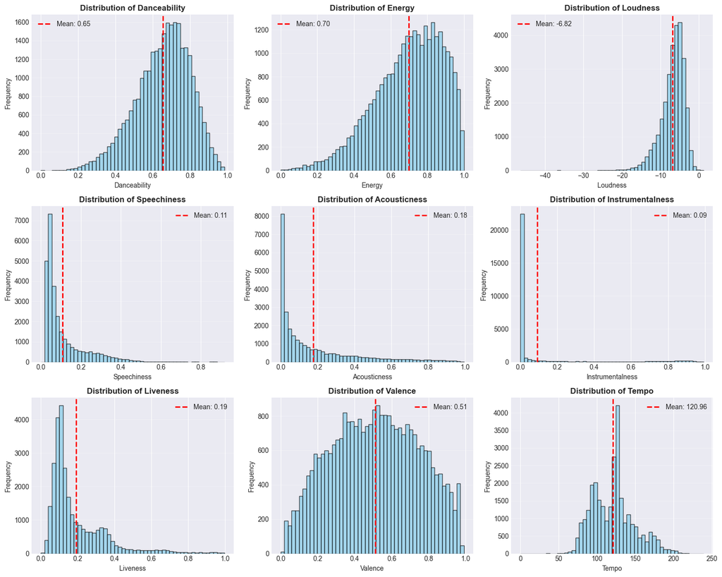

```python
fig, axes = plt.subplots(3, 3, figsize=(15, 12))
axes = axes.ravel()

for idx, feature in enumerate(audio_features):
    axes[idx].hist(df_spotify[feature], bins=50, color='skyblue', edgecolor='black', alpha=0.7)
    axes[idx].set_title(f'Distribution of {feature.capitalize()}', fontsize=12, fontweight='bold')
    axes[idx].set_xlabel(feature.capitalize())
    axes[idx].set_ylabel('Frequency')
    axes[idx].grid(axis='y', alpha=0.3)

    mean_val = df_spotify[feature].mean()
    axes[idx].axvline(mean_val, color='red', linestyle='--', linewidth=2, label=f'Mean: {mean_val:.2f}')
    axes[idx].legend()

plt.tight_layout()
plt.show()
```

```python
stats_df = df_spotify[audio_features].describe().T
stats_df['range'] = stats_df['max'] - stats_df['min']

display(stats_df.style.set_caption("Audio Features Statistics Summary"))
```

Audio Features Statistics Summary

|  | count | mean | std | min | 25% | 50% | 75% | max | range |
| --- | --- | --- | --- | --- | --- | --- | --- | --- | --- |
| danceability | 28356.000000 | 0.653372 | 0.145785 | 0.000000 | 0.561000 | 0.670000 | 0.760000 | 0.983000 | 0.983000 |
| energy | 28356.000000 | 0.698388 | 0.183503 | 0.000175 | 0.579000 | 0.722000 | 0.843000 | 1.000000 | 0.999825 |
| loudness | 28356.000000 | -6.817696 | 3.036243 | -46.448000 | -8.309250 | -6.261000 | -4.709000 | 1.275000 | 47.723000 |
| speechiness | 28356.000000 | 0.107954 | 0.102556 | 0.000000 | 0.041000 | 0.062600 | 0.133000 | 0.918000 | 0.918000 |
| acousticness | 28356.000000 | 0.177176 | 0.222803 | 0.000000 | 0.014375 | 0.079700 | 0.260000 | 0.994000 | 0.994000 |
| instrumentalness | 28356.000000 | 0.091117 | 0.232548 | 0.000000 | 0.000000 | 0.000021 | 0.006570 | 0.994000 | 0.994000 |
| liveness | 28356.000000 | 0.190958 | 0.155894 | 0.000000 | 0.092600 | 0.127000 | 0.249000 | 0.996000 | 0.996000 |
| valence | 28356.000000 | 0.510387 | 0.234340 | 0.000000 | 0.329000 | 0.512000 | 0.695000 | 0.991000 | 0.991000 |
| tempo | 28356.000000 | 120.956180 | 26.954560 | 0.000000 | 99.972000 | 121.993000 | 133.999000 | 239.440000 | 239.440000 |

Examining audio feature summaries reveals important patterns:

- **Danceability:** Mean ≈ 0.65 — many tracks are rhythmically suitable for dancing.
- **Energy:** Mean ≈ 0.70 — the dataset leans heavily toward high-energy music.
- **Acousticness:** Low average (≈ 0.18), suggesting most tracks are electronically produced.
- **Valence:** Mean ≈ 0.51 — balanced between “happy” and “sad” music.
- **Tempo:** Median ≈ 122 BPM — typical of pop and electronic genres.

These distributions help us interpret similarity scores later and anticipate which musical attributes will dominate clustering or distance metrics.

## 3.2 Genre Distribution Analysis

Understanding genre representation is crucial because imbalanced categories can bias recommendations.

### Playlist Genre Analysis

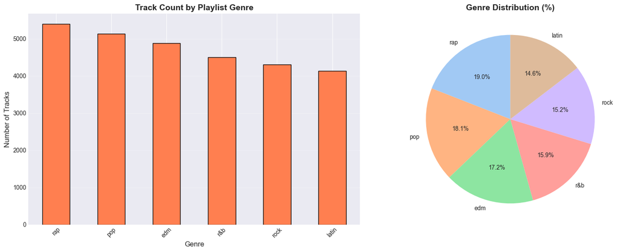

```python
genre_counts = df_spotify['playlist_genre'].value_counts()
fig, (ax1, ax2) = plt.subplots(1, 2, figsize=(16, 6))

# Bar plot of genre counts
genre_counts.plot(kind='bar', ax=ax1, color='coral', edgecolor='black')
ax1.set_title('Track Count by Playlist Genre', fontsize=14, fontweight='bold')
ax1.set_xlabel('Genre', fontsize=12)
ax1.set_ylabel('Number of Tracks', fontsize=12)
ax1.tick_params(axis='x', rotation=45)
ax1.grid(axis='y', alpha=0.3)

# Pie chart of genre distribution
ax2.pie(genre_counts.values, labels=genre_counts.index, autopct='%1.1f%%', startangle=90,
        colors=sns.color_palette('pastel'))
ax2.set_title('Genre Distribution (%)', fontsize=14, fontweight='bold')
plt.tight_layout()
plt.show()
```

```python
display(Markdown(f"**Total genres:** {df_spotify['playlist_genre'].nunique()}"))
display(Markdown(f"**Total subgenres:** {df_spotify['playlist_subgenre'].nunique()}"))

display(Markdown("##### Top 10 Genres"))
display(genre_counts.head(10).to_frame())
```

**Total genres:** 6

**Total subgenres:** 24

Top 10 Genres

| playlist_genre | count |
| --- | --- |
| rap | 5401 |
| pop | 5132 |
| edm | 4877 |
| r&b | 4504 |
| rock | 4305 |
| latin | 4137 |

```python
for genre in df_spotify['playlist_genre'].unique()[:5]:
    subgenres = df_spotify[df_spotify['playlist_genre'] == genre]['playlist_subgenre'].value_counts()
    display(Markdown(f"##### {genre.upper()} - Top 5 Subgenres"))
    display(subgenres.head().to_frame().style.set_caption(f"Subgenre Counts for {genre}"))
```

POP - Top 5 Subgenres

Subgenre Counts for pop

| playlist_subgenre | count |
| --- | --- |
| indie poptimism | 1547 |
| dance pop | 1298 |
| electropop | 1251 |
| post-teen pop | 1036 |

RAP - Top 5 Subgenres

Subgenre Counts for rap

| playlist_subgenre | count |
| --- | --- |
| southern hip hop | 1583 |
| gangster rap | 1316 |
| hip hop | 1296 |
| trap | 1206 |

ROCK - Top 5 Subgenres

Subgenre Counts for rock

| playlist_subgenre | count |
| --- | --- |
| hard rock | 1202 |
| classic rock | 1100 |
| album rock | 1039 |
| permanent wave | 964 |

LATIN - Top 5 Subgenres

Subgenre Counts for latin

| playlist_subgenre | count |
| --- | --- |
| latin hip hop | 1194 |
| tropical | 1158 |
| latin pop | 1097 |
| reggaeton | 688 |

R&B - Top 5 Subgenres

Subgenre Counts for r&b

| playlist_subgenre | count |
| --- | --- |
| neo soul | 1478 |
| urban contemporary | 1187 |
| new jack swing | 1036 |
| hip pop | 803 |

- **Total genres:** 6
- **Total subgenres:** 24

Most represented genres:

1. rap — 5,401 tracks
2. pop — 5,132 tracks
3. edm — 4,877 tracks
4. r&b — 4,504 tracks
5. rock — 4,305 tracks
6. latin — 4,137 tracks

Subgenre breakdowns show meaningful internal diversity (e.g., *indie poptimism*, *southern hip hop*, *classic rock*).  
This diversity suggests that models may detect rich substructures within broader genres.

## 3.3 Feature Correlation Analysis

Correlations reveal how audio features move together and help identify redundancy.

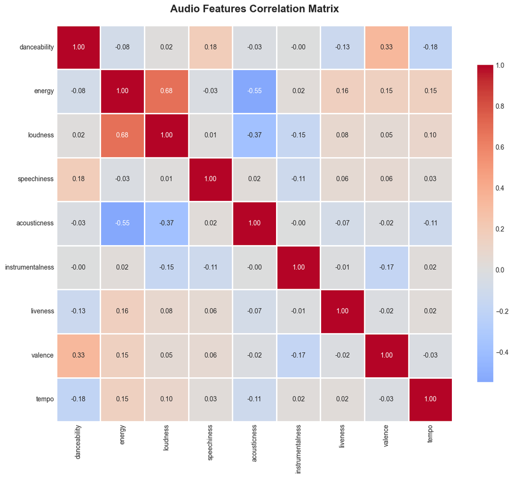

Highly Correlated Features (|r| > 0.5)

|  | Feature 1 | Feature 2 | Correlation |
| --- | --- | --- | --- |
| 0 | energy | loudness | 0.682138 |
| 1 | energy | acousticness | -0.545886 |

```python
correlation_matrix = df_spotify[audio_features].corr()

plt.figure(figsize=(12, 10))
sns.heatmap(correlation_matrix, annot=True, fmt='.2f', cmap='coolwarm',
            center=0, square=True, linewidths=1, cbar_kws={"shrink": 0.8})
plt.title('Audio Features Correlation Matrix', fontsize=16, fontweight='bold', pad=20)
plt.tight_layout()
plt.show()

high_corr = []
for i in range(len(correlation_matrix.columns)):
    for j in range(i+1, len(correlation_matrix.columns)):
        if abs(correlation_matrix.iloc[i, j]) > 0.5:
            high_corr.append({
                'Feature 1': correlation_matrix.columns[i],
                'Feature 2': correlation_matrix.columns[j],
                'Correlation': correlation_matrix.iloc[i, j]
            })

if high_corr:
    display(Markdown("#### Highly Correlated Features (|r| > 0.5)"))
    high_corr_df = pd.DataFrame(high_corr).sort_values('Correlation', ascending=False)
    display(high_corr_df)
else:
    display(Markdown("**No highly correlated features found (|r| > 0.5)**"))
```

Notable relationships:

- **Energy ↔ Loudness:** r ≈ 0.68 — louder tracks tend to be more energetic.
- **Energy ↔ Acousticness:** r ≈ –0.55 — highly energetic tracks are typically less acoustic.

These relationships indicate that certain features convey overlapping musical information, which affects how similarity metrics behave.

## 3.4 Genre-Specific Feature Profiles

Averaging audio features within each genre highlights distinct “audio signatures.”

These profiles confirm that genres are meaningfully separated in audio-feature space, which benefits clustering-based recommenders.

We also identify the most distinctive features per genre. For example:

- **Rap:** speechiness, tempo, loudness
- **EDM:** tempo, loudness, instrumentalness
- **R&B:** tempo, energy variations
- **Rock:** loudness and lower danceability

Such distinctive patterns help justify weighting or normalization choices in later modeling.

```python
genre_profiles = df_spotify.groupby('playlist_genre')[audio_features].mean()
top_genres = df_spotify['playlist_genre'].value_counts().head(5).index

scaler = MinMaxScaler()
genre_profiles_scaled = pd.DataFrame(
    scaler.fit_transform(genre_profiles),
    index=genre_profiles.index,
    columns=genre_profiles.columns
)

fig = go.Figure()
for genre in top_genres:
    fig.add_trace(go.Scatterpolar(
        r=genre_profiles_scaled.loc[genre].values.tolist() + [genre_profiles_scaled.loc[genre].values[0]],
        theta=audio_features + [audio_features[0]],
        fill='toself',
        name=genre.capitalize()
    ))
```

### Audio Feature Profiles by Genre (Normalized)

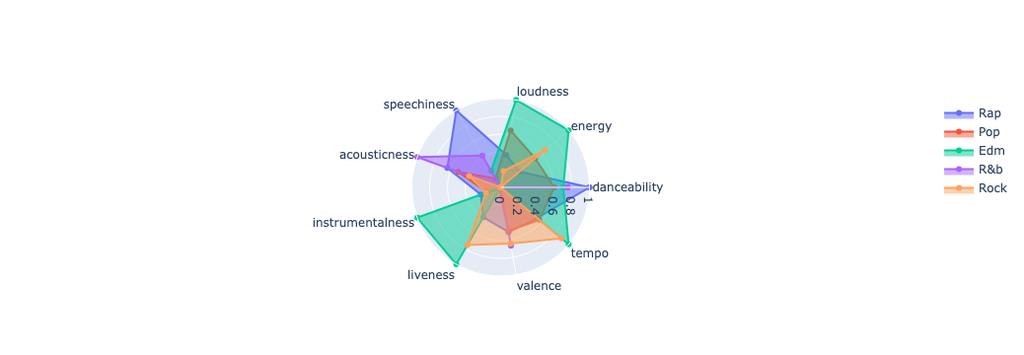

```python
fig.update_layout(
    polar=dict(
        radialaxis=dict(visible=True, range=[0, 1])
    ),
    showlegend=True,
    title=None,
    title_font_size=16
)
fig.show()
```

#### Genre Audio Profiles (Mean Values)

```python
display(genre_profiles.round(3))
```

| playlist_genre | danceability | energy | loudness | speechiness | acousticness | instrumentalness | liveness | valence | tempo |
| --- | --- | --- | --- | --- | --- | --- | --- | --- | --- |
| edm | 0.658 | 0.810 | -5.487 | 0.088 | 0.077 | 0.245 | 0.214 | 0.397 | 126.328 |
| latin | 0.711 | 0.710 | -6.483 | 0.100 | 0.213 | 0.053 | 0.182 | 0.607 | 118.523 |
| pop | 0.638 | 0.701 | -6.377 | 0.074 | 0.172 | 0.063 | 0.177 | 0.502 | 120.963 |
| r&b | 0.667 | 0.589 | -8.033 | 0.116 | 0.264 | 0.029 | 0.176 | 0.538 | 113.917 |
| rap | 0.716 | 0.650 | -7.089 | 0.197 | 0.197 | 0.080 | 0.191 | 0.505 | 120.579 |
| rock | 0.519 | 0.733 | -7.560 | 0.058 | 0.147 | 0.066 | 0.205 | 0.533 | 125.039 |

#### Most Distinctive Features by Genre

```python
for genre in top_genres:
    genre_data = df_spotify[df_spotify['playlist_genre'] == genre][audio_features]
    overall_mean = df_spotify[audio_features].mean()
    differences = (genre_data.mean() - overall_mean).abs().sort_values(ascending=False)

    display(Markdown(f"#### {genre.upper()}"))
    top3_features = differences.head(3).to_dict()
    display(Markdown(f"Top 3 distinctive features: {top3_features}"))
```

RAP

Top 3 distinctive features: {'tempo': 0.37736159494373567, 'loudness': 0.2713751958429782, 'speechiness': 0.08947890391347466}

POP

Top 3 distinctive features: {'loudness': 0.4406442653130709, 'speechiness': 0.03379260020162311, 'instrumentalness': 0.027708032473976074}

EDM

Top 3 distinctive features: {'tempo': 5.371908207043518, 'loudness': 1.330503570750607, 'instrumentalness': 0.1536766069093906}

R&B

Top 3 distinctive features: {'tempo': 7.03931428695725, 'loudness': 1.2157663536707979, 'energy': 0.10945559274939276}

ROCK

Top 3 distinctive features: {'tempo': 4.083272070607464, 'loudness': 0.7421219840770137, 'danceability': 0.13485338126301594}

## 3.5 Popularity Analysis

To understand whether audio features predict mainstream success, we examine correlations with popularity.

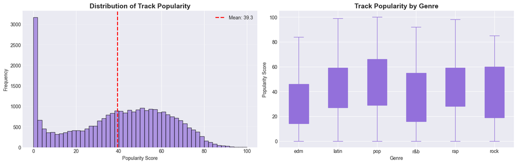

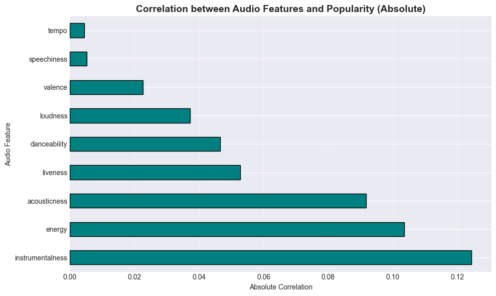

Correlation of Audio Features with Track Popularity

|  | track_popularity |
| --- | --- |
| acousticness | 0.091725 |
| danceability | 0.046597 |
| loudness | 0.037285 |
| valence | 0.022581 |
| speechiness | 0.005206 |
| tempo | 0.004446 |
| liveness | -0.052773 |
| energy | -0.103622 |
| instrumentalness | -0.124431 |

```python
fig, axes = plt.subplots(1, 2, figsize=(15, 5))

axes[0].hist(df_spotify['track_popularity'], bins=50, color='mediumpurple', edgecolor='black', alpha=0.7)
axes[0].set_title('Distribution of Track Popularity', fontsize=14, fontweight='bold')
axes[0].set_xlabel('Popularity Score')
axes[0].set_ylabel('Frequency')
axes[0].axvline(df_spotify['track_popularity'].mean(), color='red', linestyle='--', linewidth=2, label=f'Mean: {df_spotify["track_popularity"].mean():.1f}')
axes[0].legend()
axes[0].grid(axis='y', alpha=0.3)

df_spotify.boxplot(column='track_popularity', by='playlist_genre', ax=axes[1], color='mediumpurple', patch_artist=True)
axes[1].set_title('Track Popularity by Genre', fontsize=14, fontweight='bold')
axes[1].set_xlabel('Genre')
axes[1].set_ylabel('Popularity Score')
plt.suptitle('')
plt.tight_layout()
plt.show()

popularity_corr = df_spotify[audio_features + ['track_popularity']].corr()['track_popularity'].drop('track_popularity')
popularity_corr_sorted = popularity_corr.abs().sort_values(ascending=False)

plt.figure(figsize=(10, 6))
popularity_corr_sorted.plot(kind='barh', color='teal', edgecolor='black')
plt.title('Correlation between Audio Features and Popularity (Absolute)', fontsize=14, fontweight='bold')
plt.xlabel('Absolute Correlation')
plt.ylabel('Audio Feature')
plt.grid(axis='x', alpha=0.3)
plt.tight_layout()
plt.show()

display(popularity_corr.sort_values(ascending=False).to_frame().style.set_caption("Correlation of Audio Features with Track Popularity"))
```

Key findings:

- **Weak correlations:** Most audio features have correlations between –0.12 and +0.09 with popularity.
- **Instrumentalness:** Slight negative correlation — instrumental tracks tend to be less popular.
- **Energy & Liveness:** Slight negative relationship with popularity.
- **Acousticness & Danceability:** Weak positive influence.

In short, **audio features alone do not strongly explain popularity**.  
This reinforces a common real-world insight: popularity is influenced heavily by social, cultural, and algorithmic factors—not just sound.

# **4. Feature Engineering**

Raw features rarely provide optimal inputs for machine learning models.  
Feature engineering helps transform, scale, and combine features so that our recommendation algorithms can better capture meaningful musical patterns.  
In this section, we focus on normalization, dimensionality reduction, and composite feature creation.

## 4.1 Feature Normalization

Audio features in our dataset operate on very different scales.  
For example:

- **Tempo:** typically ranges from 50–200 BPM
- **Danceability:** always between 0 and 1

Without normalization, large-scale features (like tempo) can dominate distance-based similarity calculations.

**Example:**

Song A → tempo = 120, danceability = 0.8  
Song B → tempo = 121, danceability = 0.3

If unscaled, the *1 BPM tempo difference* may outweigh the *0.5 danceability difference*, leading to misleading similarity scores.

```
Original features shape: (28356, 11)
Scaled features shape: (28356, 11)
```

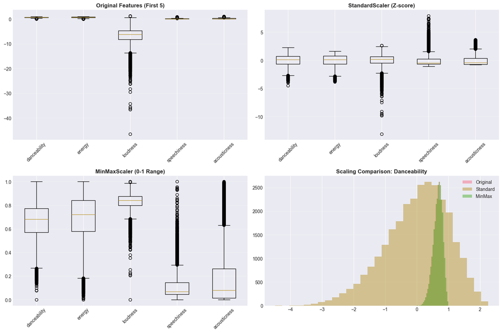

```python
numerical_features = audio_features + ['track_popularity', 'duration_ms']

feature_matrix = df_spotify[numerical_features].copy()

scaler_standard = StandardScaler()
features_scaled_standard = scaler_standard.fit_transform(feature_matrix)
df_features_standard = pd.DataFrame(
    features_scaled_standard,
    columns=numerical_features,
    index=df_spotify.index
)

scaler_minmax = MinMaxScaler()
features_scaled_minmax = scaler_minmax.fit_transform(feature_matrix)
df_features_minmax = pd.DataFrame(
    features_scaled_minmax,
    columns=numerical_features,
    index=df_spotify.index
)

print(f"\nOriginal features shape: {feature_matrix.shape}")
print(f"Scaled features shape: {df_features_standard.shape}")

fig, axes = plt.subplots(2, 2, figsize=(15, 10))

axes[0, 0].boxplot([feature_matrix[col].values for col in audio_features[:5]], labels=audio_features[:5])
axes[0, 0].set_title('Original Features (First 5)', fontsize=12, fontweight='bold')
axes[0, 0].tick_params(axis='x', rotation=45)
axes[0, 0].grid(axis='y', alpha=0.3)

axes[0, 1].boxplot([df_features_standard[col].values for col in audio_features[:5]], labels=audio_features[:5])
axes[0, 1].set_title('StandardScaler (Z-score)', fontsize=12, fontweight='bold')
axes[0, 1].tick_params(axis='x', rotation=45)
axes[0, 1].grid(axis='y', alpha=0.3)

axes[1, 0].boxplot([df_features_minmax[col].values for col in audio_features[:5]], labels=audio_features[:5])
axes[1, 0].set_title('MinMaxScaler (0-1 Range)', fontsize=12, fontweight='bold')
axes[1, 0].tick_params(axis='x', rotation=45)
axes[1, 0].grid(axis='y', alpha=0.3)

sample_feature = audio_features[0]
axes[1, 1].hist(feature_matrix[sample_feature], alpha=0.5, label='Original', bins=30)
axes[1, 1].hist(df_features_standard[sample_feature], alpha=0.5, label='Standard', bins=30)
axes[1, 1].hist(df_features_minmax[sample_feature], alpha=0.5, label='MinMax', bins=30)
axes[1, 1].set_title(f'Scaling Comparison: {sample_feature.capitalize()}', fontsize=12, fontweight='bold')
axes[1, 1].legend()
axes[1, 1].grid(axis='y', alpha=0.3)

plt.tight_layout()
plt.show()
```

#### Key Observations

- **Raw features vary dramatically in scale.**  
  Loudness spans nearly 50 dB, while danceability and energy remain within [0, 1].  
  Without scaling, large-range features dominate similarity calculations.
- **StandardScaler centers features around zero and preserves outlier structure.**  
  This can be useful for models sensitive to variance, but it still allows large values (e.g., loudness) to influence distances disproportionately.
- **MinMaxScaler compresses all features into the [0, 1] interval.**  
  This makes each audio attribute contribute more evenly to the similarity metric, which is desirable for recommendation engines based on cosine similarity or Euclidean distance.

Because the majority of Spotify audio features are already bounded, **MinMaxScaler provides the most intuitive and stable representation for content-based similarity**.

## 4.2 Dimensionality Reduction with PCA

Although we start with nine audio features, several of them carry overlapping information

**Principal Component Analysis (PCA)** helps reveal the intrinsic dimensionality of the feature space and can reduce noise and computational cost.

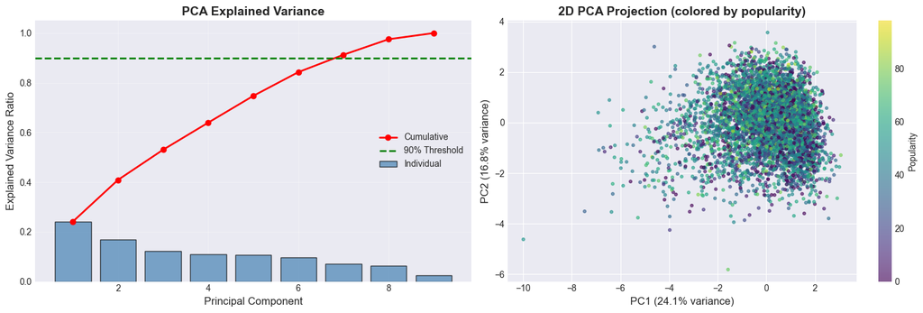

PCA Analysis Results

Number of components for 90% variance: 7

Variance explained by first 2 components: 40.86%

|  | PC | Explained Variance | Cumulative Variance |
| --- | --- | --- | --- |
| 0 | PC1 | 0.2409 | 24.09% |
| 1 | PC2 | 0.1677 | 40.86% |
| 2 | PC3 | 0.1215 | 53.01% |
| 3 | PC4 | 0.1091 | 63.92% |
| 4 | PC5 | 0.1079 | 74.71% |
| 5 | PC6 | 0.0958 | 84.28% |
| 6 | PC7 | 0.0698 | 91.27% |
| 7 | PC8 | 0.0625 | 97.51% |
| 8 | PC9 | 0.0249 | 100.00% |

```python
pca = PCA()
pca_features = pca.fit_transform(df_features_standard[audio_features])

explained_variance_ratio = pca.explained_variance_ratio_
cumulative_variance = np.cumsum(explained_variance_ratio)

n_components_90 = np.argmax(cumulative_variance >= 0.90) + 1

fig, (ax1, ax2) = plt.subplots(1, 2, figsize=(15, 5))

ax1.bar(range(1, len(explained_variance_ratio) + 1), explained_variance_ratio,
        alpha=0.7, color='steelblue', edgecolor='black', label='Individual')
ax1.plot(range(1, len(cumulative_variance) + 1), cumulative_variance,
         marker='o', color='red', linewidth=2, label='Cumulative')
ax1.axhline(y=0.90, color='green', linestyle='--', linewidth=2, label='90% Threshold')
ax1.set_xlabel('Principal Component', fontsize=12)
ax1.set_ylabel('Explained Variance Ratio', fontsize=12)
ax1.set_title('PCA Explained Variance', fontsize=14, fontweight='bold')
ax1.legend()
ax1.grid(alpha=0.3)

pca_2d = PCA(n_components=2)
pca_2d_features = pca_2d.fit_transform(df_features_standard[audio_features])

sample_indices = np.random.choice(len(pca_2d_features), size=5000, replace=False)
scatter = ax2.scatter(pca_2d_features[sample_indices, 0],
                     pca_2d_features[sample_indices, 1],
                     c=df_spotify.iloc[sample_indices]['track_popularity'],
                     cmap='viridis', alpha=0.6, s=10)
ax2.set_xlabel(f'PC1 ({pca_2d.explained_variance_ratio_[0]:.1%} variance)', fontsize=12)
ax2.set_ylabel(f'PC2 ({pca_2d.explained_variance_ratio_[1]:.1%} variance)', fontsize=12)
ax2.set_title('2D PCA Projection (colored by popularity)', fontsize=14, fontweight='bold')
plt.colorbar(scatter, ax=ax2, label='Popularity')

plt.tight_layout()
plt.show()

display(Markdown("#### PCA Analysis Results"))
display(Markdown(f"Number of components for 90% variance: {n_components_90}"))
display(Markdown(f"Variance explained by first 2 components: {cumulative_variance[1]:.2%}"))

explained_df = pd.DataFrame({
    'PC': [f'PC{i}' for i in range(1, len(explained_variance_ratio)+1)],
    'Explained Variance': explained_variance_ratio,
    'Cumulative Variance': cumulative_variance
})
display(explained_df.style.format({
    'Explained Variance': "{:.4f}",
    'Cumulative Variance': "{:.2%}"
}))
```

**Interpretation:**  
Our audio space is moderately redundant—four to seven components hold most of the structure.  
This informs future choices around clustering and similarity weighting.

## 4.3 Creating Composite Features

Sometimes combinations of features better capture musical qualities than individual attributes.  
Based on musical intuition, we engineer several domain-inspired composite features:

Composite Features Created

['energy_danceability', 'valence_energy', 'acoustic_score', 'party_score', 'chill_score', 'workout_score']

Statistical Summary of Composite Features

|  | energy_danceability | valence_energy | acoustic_score | party_score | chill_score | workout_score |
| --- | --- | --- | --- | --- | --- | --- |
| count | 28356.000000 | 28356.000000 | 28356.000000 | 28356.000000 | 28356.000000 | 28356.000000 |
| mean | 0.454129 | 0.362885 | -0.260606 | 0.620715 | 0.189968 | 0.411664 |
| std | 0.147404 | 0.199854 | 0.178852 | 0.125239 | 0.141294 | 0.087335 |
| min | 0.000000 | 0.000000 | -0.499308 | 0.030158 | 0.001224 | 0.018043 |
| 25% | 0.357652 | 0.202311 | -0.391513 | 0.540000 | 0.089696 | 0.356103 |
| 50% | 0.463097 | 0.346630 | -0.303975 | 0.626667 | 0.153667 | 0.418308 |
| 75% | 0.558945 | 0.506855 | -0.181500 | 0.713000 | 0.254333 | 0.475747 |
| max | 0.920088 | 0.965196 | 0.481150 | 0.944667 | 0.934300 | 0.662548 |

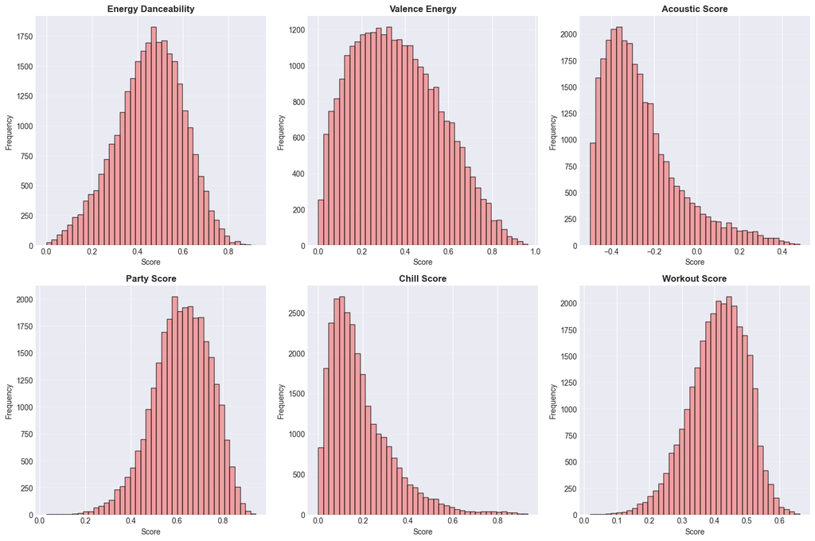

```python
df_spotify['energy_danceability'] = df_spotify['energy'] * df_spotify['danceability']
df_spotify['valence_energy'] = df_spotify['valence'] * df_spotify['energy']
df_spotify['acoustic_score'] = (df_spotify['acousticness'] - df_spotify['energy']) / 2
df_spotify['party_score'] = (df_spotify['danceability'] + df_spotify['energy'] + df_spotify['valence']) / 3
df_spotify['chill_score'] = (df_spotify['acousticness'] + (1 - df_spotify['energy']) + df_spotify['instrumentalness']) / 3
df_spotify['workout_score'] = (df_spotify['energy'] + df_spotify['tempo']/200 + df_spotify['loudness']/100) / 3

composite_features = ['energy_danceability', 'valence_energy', 'acoustic_score', 'party_score', 'chill_score', 'workout_score']

display(Markdown("#### Composite Features Created"))
display(Markdown(f"{composite_features}"))

display(Markdown("#### Statistical Summary  of Composite Features"))
display(df_spotify[composite_features].describe())

fig, axes = plt.subplots(2, 3, figsize=(15, 10))
axes = axes.ravel()

for idx, feature in enumerate(composite_features):
    axes[idx].hist(df_spotify[feature], bins=40, color='lightcoral', edgecolor='black', alpha=0.7)
    axes[idx].set_title(f'{feature.replace("_", " ").title()}', fontsize=12, fontweight='bold')
    axes[idx].set_xlabel('Score')
    axes[idx].set_ylabel('Frequency')
    axes[idx].grid(axis='y', alpha=0.3)

plt.tight_layout()
plt.show()
```

These features capture interpretable concepts:

- *party_score* blends energy, danceability, and valence
- *chill_score* highlights softer acoustic tracks
- *workout_score* emphasizes strong rhythmic patterns

# **5. Building Recommendation Models**

In this section, we implement three complementary approaches to music recommendation.  
Each method—content-based filtering, clustering, and hybrid scoring—offers different strengths and weaknesses.  
Understanding these trade-offs is essential for evaluating real-world recommender systems.

## 5.1 Content-Based Filtering with Cosine Similarity

**Core idea:** Recommend songs whose audio features are most similar to the songs a user already likes.

### How It Works

Cosine similarity is ideal for this task because it captures how *directionally similar* feature vectors are, regardless of their magnitude.

### Advantages

- **No cold start for items:** New songs with audio features can be recommended immediately.
- **Transparent:** We can explain *why* a track was recommended (e.g., “similar energy and danceability”).
- **User independence:** Works even when a user has liked only one song.

### Limitations

- **Can be narrow:** Often recommends songs that sound *too* similar.
- **No collective insight:** Does not leverage what other listeners enjoy.
- **Risk of filter bubbles:** Users may miss surprising or diverse content.

Content-based filtering forms the backbone of many modern music systems, especially for early personalization.

```python
content_features = audio_features + composite_features
feature_matrix_content = df_spotify[content_features].reset_index(drop=True)

display(Markdown("Calculating cosine similarity matrix..."))
cosine_sim_matrix = cosine_similarity(feature_matrix_content)
display(Markdown(f"Similarity matrix shape: {cosine_sim_matrix.shape}"))

track_indices = pd.Series(df_spotify.index, index=df_spotify['track_name']).to_dict()

def get_content_based_recommendations(track_name, n_recommendations=10, show_features=False):
    if track_name not in track_indices:
        possible_matches = [t for t in track_indices.keys() if track_name.lower() in t.lower()]
        if possible_matches:
            display(Markdown(f"Track '{track_name}' not found. Did you mean one of these?"))
            for i, match in enumerate(possible_matches[:5], 1):
                display(Markdown(f"  {i}. {match}"))
            return None
        else:
            display(Markdown(f"Track '{track_name}' not found in dataset."))
            return None

    idx = track_indices[track_name]
    sim_scores = list(enumerate(cosine_sim_matrix[idx]))
    sim_scores = sorted(sim_scores, key=lambda x: x[1], reverse=True)[1:n_recommendations+1]
    track_idxs = [i[0] for i in sim_scores]
    similarity_scores = [i[1] for i in sim_scores]

    recommendations = df_spotify.iloc[track_idxs][['track_name', 'track_artist',
                                                    'playlist_genre', 'track_popularity']].copy()
    recommendations['similarity_score'] = similarity_scores
    recommendations = recommendations.reset_index(drop=True)
    recommendations.index += 1

    input_track = df_spotify[df_spotify['track_name'] == track_name].iloc[0]
    display(Markdown("#### Input Track"))
    display(Markdown(f"Track: {input_track['track_name']}"))
    display(Markdown(f"Artist: {input_track['track_artist']}"))
    display(Markdown(f"Genre: {input_track['playlist_genre']}"))
    display(Markdown(f"Popularity: {input_track['track_popularity']}"))

    display(Markdown(f"#### Top {n_recommendations} Recommendations"))
    display(recommendations.style.set_caption("Recommended Tracks with Content Based Similarity Scores"))

    if show_features:
        input_features = df_spotify.loc[idx, audio_features]
        rec_features = df_spotify.iloc[track_idxs[0], :][audio_features]
        comparison_df = pd.DataFrame({
            'Input Track': input_features,
            'Top Recommendation': rec_features,
            'Difference': abs(input_features - rec_features)
        })
        display(Markdown("##### Audio Feature Comparision"))
        display(comparison_df.round(3).style.set_caption("Input Track vs Top Recommendation"))

    return recommendations

test_track = df_spotify['track_name'].iloc[100]
recommendations_content = get_content_based_recommendations(test_track, n_recommendations=10, show_features=True)
```

Calculating cosine similarity matrix...

Similarity matrix shape: (28356, 28356)

Input Track

Track: Don't Call Me Up

Artist: Mabel

Genre: pop

Popularity: 85

Top 10 Recommendations

Recommended Tracks with Content Based Similarity Scores

|  | track_name | track_artist | playlist_genre | track_popularity | similarity_score |
| --- | --- | --- | --- | --- | --- |
| 1 | 2Kaiser (Street) | Seryoga | rap | 16 | 0.999998 |
| 2 | Veneno | BB Nobre | latin | 49 | 0.999998 |
| 3 | Till The End | Swanky Tunes | pop | 42 | 0.999997 |
| 4 | Broken Heart | Fullife | r&b | 18 | 0.999997 |
| 5 | Mr. Ferrari | GASHI | r&b | 54 | 0.999996 |
| 6 | Bleib mal locker, Lan | Milonair | rap | 1 | 0.999995 |
| 7 | Oversized | Kramder | edm | 28 | 0.999995 |
| 8 | Celebra | Toda la Vida | latin | 39 | 0.999995 |
| 9 | Savannah | Diviners | pop | 58 | 0.999995 |
| 10 | Nothing Breaks Like a Heart - Don Diablo Remix | Mark Ronson | edm | 66 | 0.999995 |

Audio Feature Comparision

Input Track vs Top Recommendation

|  | Input Track | Top Recommendation | Difference |
| --- | --- | --- | --- |
| danceability | 0.674000 | 0.763000 | 0.089000 |
| energy | 0.881000 | 0.818000 | 0.063000 |
| loudness | -2.853000 | -2.778000 | 0.075000 |
| speechiness | 0.147000 | 0.184000 | 0.037000 |
| acousticness | 0.296000 | 0.257000 | 0.039000 |
| instrumentalness | 0.000003 | 0.000000 | 0.000003 |
| liveness | 0.079300 | 0.084500 | 0.005200 |
| valence | 0.234000 | 0.211000 | 0.023000 |
| tempo | 98.994000 | 101.090000 | 2.096000 |

## 5.2 Clustering-Based Recommendations

**Core idea:** Group songs into clusters based on audio similarity, then recommend tracks from the same cluster.

Clustering creates a high-level structure of the musical landscape.  
Two songs might not have the highest cosine similarity but still belong to the same “musical neighborhood.”

### Why Clustering Helps

- **Improved diversity:** Recommendations come from a broader but relevant pool.
- **Scalability:** Once clusters are computed, recommending within them is extremely fast.
- **Interpretability:** Clusters often correspond to musical styles or moods.

Finding optimal number of clusters...

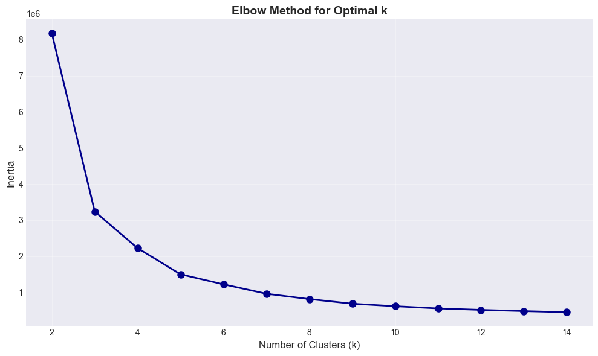

K-Means clustering complete with k=8

Cluster Distribution

Number of Tracks per Cluster

| cluster | count |
| --- | --- |
| 0 | 2895 |
| 1 | 5469 |
| 2 | 1856 |
| 3 | 8720 |
| 4 | 4091 |
| 5 | 566 |
| 6 | 2055 |
| 7 | 2704 |

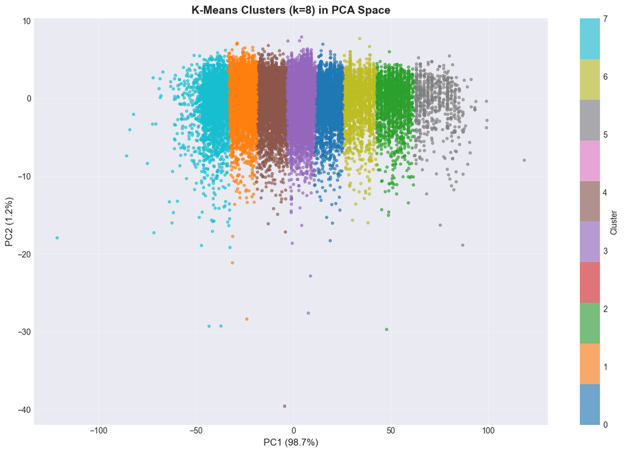

Cluster Audio Profile

Mean Audio Features by Cluster

| cluster | danceability | energy | loudness | speechiness | acousticness | instrumentalness | liveness | valence | tempo |
| --- | --- | --- | --- | --- | --- | --- | --- | --- | --- |
| 0 | 0.631000 | 0.683000 | -7.046000 | 0.102000 | 0.189000 | 0.080000 | 0.193000 | 0.483000 | 139.381000 |
| 1 | 0.695000 | 0.678000 | -6.779000 | 0.123000 | 0.198000 | 0.040000 | 0.184000 | 0.560000 | 95.296000 |
| 2 | 0.563000 | 0.699000 | -6.615000 | 0.150000 | 0.195000 | 0.048000 | 0.191000 | 0.551000 | 172.852000 |
| 3 | 0.675000 | 0.754000 | -6.299000 | 0.084000 | 0.121000 | 0.160000 | 0.198000 | 0.470000 | 125.378000 |
| 4 | 0.689000 | 0.691000 | -7.216000 | 0.081000 | 0.181000 | 0.061000 | 0.182000 | 0.545000 | 109.752000 |
| 5 | 0.522000 | 0.702000 | -6.644000 | 0.180000 | 0.161000 | 0.053000 | 0.181000 | 0.538000 | 193.547000 |
| 6 | 0.594000 | 0.717000 | -6.545000 | 0.127000 | 0.161000 | 0.063000 | 0.200000 | 0.510000 | 153.994000 |
| 7 | 0.603000 | 0.573000 | -8.104000 | 0.143000 | 0.299000 | 0.090000 | 0.188000 | 0.485000 | 79.897000 |

Cluster Based Recommendation (Cluster 1)

Top 10 Tracks from Cluster 1

|  | track_name | track_artist | playlist_genre | track_popularity | cluster |
| --- | --- | --- | --- | --- | --- |
| 1 | Dance Monkey | Tones and I | pop | 100 | 1 |
| 2 | Tusa | KAROL G | pop | 98 | 1 |
| 3 | Memories | Maroon 5 | pop | 98 | 1 |
| 4 | Lose You To Love Me | Selena Gomez | pop | 93 | 1 |
| 5 | Vete | Bad Bunny | rap | 93 | 1 |
| 6 | Dance Monkey | Tones and I | pop | 92 | 1 |
| 7 | Fantasias | Rauw Alejandro | pop | 92 | 1 |
| 8 | Adore You | Harry Styles | pop | 91 | 1 |
| 9 | 10,000 Hours (with Justin Bieber) | Dan + Shay | pop | 91 | 1 |
| 10 | South of the Border (feat. Camila Cabello & Cardi B) | Ed Sheeran | pop | 91 | 1 |

```python
inertias = []
K_range = range(2, 15)

display(Markdown("Finding optimal number of clusters..."))
for k in K_range:
    kmeans = KMeans(n_clusters=k, random_state=42, n_init=10)
    kmeans.fit(feature_matrix_content)
    inertias.append(kmeans.inertia_)

plt.figure(figsize=(10, 6))
plt.plot(K_range, inertias, marker='o', linewidth=2, markersize=8, color='darkblue')
plt.xlabel('Number of Clusters (k)', fontsize=12)
plt.ylabel('Inertia', fontsize=12)
plt.title('Elbow Method for Optimal k', fontsize=14, fontweight='bold')
plt.grid(alpha=0.3)
plt.tight_layout()
plt.show()

optimal_k = 8
kmeans = KMeans(n_clusters=optimal_k, random_state=42, n_init=10)
df_spotify['cluster'] = kmeans.fit_predict(feature_matrix_content)

display(Markdown(f"K-Means clustering complete with k={optimal_k}"))
display(Markdown("#### Cluster Distribution"))
display(df_spotify['cluster'].value_counts().sort_index().to_frame().style.set_caption("Number of Tracks per Cluster"))

cluster_profiles = df_spotify.groupby('cluster')[audio_features].mean()

pca_viz = PCA(n_components=2)
pca_features_viz = pca_viz.fit_transform(feature_matrix_content)

plt.figure(figsize=(12, 8))
scatter = plt.scatter(pca_features_viz[:, 0], pca_features_viz[:, 1], c=df_spotify['cluster'], cmap='tab10', alpha=0.6, s=10)
plt.xlabel(f'PC1 ({pca_viz.explained_variance_ratio_[0]:.1%})', fontsize=12)
plt.ylabel(f'PC2 ({pca_viz.explained_variance_ratio_[1]:.1%})', fontsize=12)
plt.title(f'K-Means Clusters (k={optimal_k}) in PCA Space', fontsize=14, fontweight='bold')
plt.colorbar(scatter, label='Cluster')
plt.grid(alpha=0.3)
plt.tight_layout()
plt.show()

display(Markdown("#### Cluster Audio Profile"))
display(cluster_profiles.round(3).style.set_caption("Mean Audio Features by Cluster"))

def get_cluster_based_recommendations(track_name, n_recommendations=10):
    if track_name not in track_indices:
        display(Markdown(f"Track '{track_name}' not found."))
        return None

    idx = track_indices[track_name]
    track_cluster = df_spotify.iloc[idx]['cluster']

    cluster_tracks = df_spotify[
        (df_spotify['cluster'] == track_cluster) &
        (df_spotify.index != idx)
    ]

    recommendations = cluster_tracks.nlargest(n_recommendations, 'track_popularity')[
        ['track_name', 'track_artist', 'playlist_genre', 'track_popularity', 'cluster']
    ].copy()

    recommendations = recommendations.reset_index(drop=True)
    recommendations.index += 1

    display(Markdown(f"#### Cluster Based Recommendation (Cluster {track_cluster})"))
    display(recommendations.style.set_caption(f"Top {n_recommendations} Tracks from Cluster {track_cluster}"))

    return recommendations

recommendations_cluster = get_cluster_based_recommendations(test_track, n_recommendations=10)
```

### Cluster Audio Profiles Intuition

These profiles reveal how songs are grouped and help explain recommendations within each cluster.

## 5.3 Hybrid Recommendation System

**Core idea:** Combine content similarity with cluster-level structure for more balanced recommendations.

### Why Hybrid Works Well

- **Balances accuracy and diversity:** Content similarity ensures relevance; clusters ensure variety.
- **More robust:** Reduces weaknesses of single-method systems.
- **Better personalization:** Captures both fine-grained and broad musical characteristics.

### Hybrid Scoring Formula

We combine:

- **Content similarity weight:** 0.6
- **Cluster similarity weight:** 0.4

Hybrid Score  
= 0.6 × (cosine similarity) + 0.4 × (cluster match score)

A cluster match boosts songs that share broader musical context, even if they’re not the top cosine matches.

```python
def get_hybrid_recommendations(track_name, n_recommendations=10, content_weight=0.6, cluster_weight=0.4):
    if track_name not in track_indices:
        display(Markdown(f"Track '{track_name}' not found."))
        return None

    idx = track_indices[track_name]
    track_cluster = df_spotify.iloc[idx]['cluster']

    content_scores = cosine_sim_matrix[idx]
    cluster_scores = (df_spotify['cluster'] == track_cluster).astype(float).values
    hybrid_scores = (content_weight * content_scores) + (cluster_weight * cluster_scores)

    hybrid_scores[idx] = -1
    top_indices = hybrid_scores.argsort()[-n_recommendations:][::-1]

    recommendations = df_spotify.iloc[top_indices][
        ['track_name', 'track_artist', 'playlist_genre', 'track_popularity', 'cluster']
    ].copy()

    recommendations['hybrid_score'] = hybrid_scores[top_indices]
    recommendations['content_similarity'] = content_scores[top_indices]
    recommendations['same_cluster'] = (df_spotify.iloc[top_indices]['cluster'] == track_cluster).values

    recommendations = recommendations.reset_index(drop=True)
    recommendations.index += 1

    display(Markdown(f"####  Top Hybrid Recommended Tracks(Content: {content_weight}, Cluster: {cluster_weight})"))
    display(recommendations)

    return recommendations

recommendations_hybrid = get_hybrid_recommendations(test_track, n_recommendations=10)
```

Top Hybrid Recommended Tracks(Content: 0.6, Cluster: 0.4)

|  | track_name | track_artist | playlist_genre | track_popularity | cluster | hybrid_score | content_similarity | same_cluster |
| --- | --- | --- | --- | --- | --- | --- | --- | --- |
| 1 | 2Kaiser (Street) | Seryoga | rap | 16 | 1 | 0.999999 | 0.999998 | True |
| 2 | Veneno | BB Nobre | latin | 49 | 1 | 0.999999 | 0.999998 | True |
| 3 | Mr. Ferrari | GASHI | r&b | 54 | 1 | 0.999997 | 0.999996 | True |
| 4 | Bleib mal locker, Lan | Milonair | rap | 1 | 1 | 0.999997 | 0.999995 | True |
| 5 | Pa' Mala Yo | Natti Natasha | latin | 53 | 1 | 0.999997 | 0.999994 | True |
| 6 | All the Time | Zara Larsson | pop | 74 | 1 | 0.999996 | 0.999993 | True |
| 7 | Drama (Party Favor Remix) | Bro Safari | edm | 38 | 1 | 0.999995 | 0.999992 | True |
| 8 | Californication | Red Hot Chili Peppers | rock | 81 | 1 | 0.999995 | 0.999992 | True |
| 9 | Loco Contigo (with J. Balvin & Tyga) | DJ Snake | latin | 48 | 1 | 0.999995 | 0.999992 | True |
| 10 | WILD - Young Bombs Remix | Troye Sivan | edm | 0 | 1 | 0.999995 | 0.999991 | True |

## 5.4 Genre-Based Filtering

While content-based similarity captures fine-grained audio characteristics, many listeners prefer recommendations that stay within a specific genre or mood.  
Genre-based filtering adds this control by restricting recommendations to songs belonging to a particular genre.

### Core Idea

**Recommend only songs from a chosen genre, ranked by cosine similarity.**

This approach is useful when:

- A user wants more songs in a familiar genre
- Genre-specific playlists are being generated
- We want to avoid cross-genre drift (e.g., recommending EDM songs for a jazz listener)

```python
def get_genre_filtered_recommendations(track_name, genre=None, n_recommendations=10):
    if track_name not in track_indices:
        display(Markdown(f"Track '{track_name}' not found."))
        return None

    idx = track_indices[track_name]

    if genre is None:
        genre = df_spotify.iloc[idx]['playlist_genre']

    genre_mask = df_spotify['playlist_genre'] == genre

    sim_scores = []
    for i, is_in_genre in enumerate(genre_mask):
        if is_in_genre and i != idx:
            sim_scores.append((i, cosine_sim_matrix[idx][i]))

    sim_scores = sorted(sim_scores, key=lambda x: x[1], reverse=True)[:n_recommendations]

    track_idxs = [i[0] for i in sim_scores]
    similarity_scores = [i[1] for i in sim_scores]

    recommendations = df_spotify.iloc[track_idxs][
        ['track_name', 'track_artist', 'playlist_genre', 'playlist_subgenre', 'track_popularity']
    ].copy()
    recommendations['similarity_score'] = similarity_scores
    recommendations = recommendations.reset_index(drop=True)
    recommendations.index += 1

    display(Markdown(f"#### Genre-Filtered Recommendations (Genre: {genre})"))
    display(recommendations.style.set_caption(f"Top {n_recommendations} Tracks in Genre '{genre}'"))

    return recommendations

recommendations_genre = get_genre_filtered_recommendations(test_track, n_recommendations=10)
```

Genre-Filtered Recommendations (Genre: pop)

Top 10 Tracks in Genre 'pop'

|  | track_name | track_artist | playlist_genre | playlist_subgenre | track_popularity | similarity_score |
| --- | --- | --- | --- | --- | --- | --- |
| 1 | Till The End | Swanky Tunes | pop | indie poptimism | 42 | 0.999997 |
| 2 | Savannah | Diviners | pop | electropop | 58 | 0.999995 |
| 3 | Ciao Adios | Anne-Marie | pop | indie poptimism | 64 | 0.999994 |
| 4 | Let Me Hold You (Turn Me On) | Dante Klein | pop | electropop | 51 | 0.999994 |
| 5 | If I Loved You | Royse | pop | dance pop | 38 | 0.999993 |
| 6 | All the Time | Zara Larsson | pop | dance pop | 74 | 0.999993 |
| 7 | When I'm With U | Tritonal | pop | indie poptimism | 54 | 0.999993 |
| 8 | Nuh Ready Nuh Ready | Calvin Harris | pop | electropop | 55 | 0.999992 |
| 9 | Play It Cool | Monsta X | pop | dance pop | 56 | 0.999992 |
| 10 | Heaven (feat. Veronica) | Dzeko | pop | dance pop | 68 | 0.999991 |

# **6. Evaluation and Results**

How do we know if our recommendations are actually useful?  
Visual inspection is helpful, but not enough. In this section we:

- Quantify **diversity** of recommendation lists
- Simulate **different user profiles**
- Examine **cold-start behavior** for low-popularity tracks

Together, these analyses give a more complete picture of system quality.

## 6.1 Recommendation Diversity Analysis

Recommender systems often suffer from the **filter bubble** problem: they keep recommending items that look almost identical to what the user already knows.  
To study this, we compare several models using a small set of diversity metrics.

Diversity Metrics Across Recommendation Methods

|  | avg_inter_similarity | genre_diversity | unique_genres | popularity_variance |
| --- | --- | --- | --- | --- |
| Content-Based | 0.999900 | 0.833300 | 5.000000 | 435.877800 |
| Cluster-Based | 0.999900 | 0.333300 | 2.000000 | 11.655600 |
| Hybrid | 0.999900 | 1.000000 | 6.000000 | 780.933300 |
| Genre-Filtered | 0.999900 | 0.166700 | 1.000000 | 120.666700 |

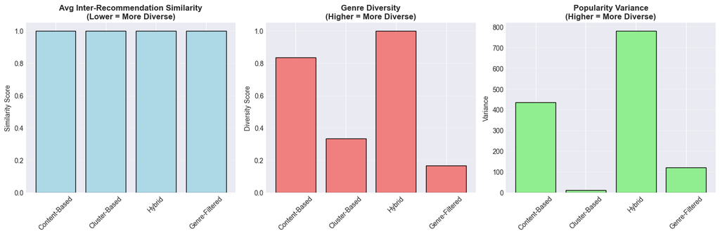

```python
def calculate_diversity_metrics(recommendations, input_idx):
    rec_indices = recommendations.index.tolist()
    rec_features = feature_matrix_content.iloc[rec_indices]
    inter_sim_matrix = cosine_similarity(rec_features)

    mask = ~np.eye(inter_sim_matrix.shape[0], dtype=bool)
    avg_inter_similarity = inter_sim_matrix[mask].mean()

    genres = recommendations['playlist_genre'].nunique()
    total_genres = df_spotify['playlist_genre'].nunique()
    genre_diversity = genres / total_genres

    pop_variance = recommendations['track_popularity'].var()

    return {
        'avg_inter_similarity': avg_inter_similarity,
        'genre_diversity': genre_diversity,
        'unique_genres': genres,
        'popularity_variance': pop_variance
    }


methods = {
    'Content-Based': recommendations_content,
    'Cluster-Based': recommendations_cluster,
    'Hybrid': recommendations_hybrid,
    'Genre-Filtered': recommendations_genre
}

diversity_results = {}
for method_name, recs in methods.items():
    if recs is not None:
        metrics = calculate_diversity_metrics(recs, track_indices[test_track])
        diversity_results[method_name] = metrics

diversity_df = pd.DataFrame(diversity_results).T
display(diversity_df.round(4).style.set_caption("Diversity Metrics Across Recommendation Methods"))

fig, axes = plt.subplots(1, 3, figsize=(15, 5))

axes[0].bar(diversity_df.index, diversity_df['avg_inter_similarity'], color='lightblue', edgecolor='black')
axes[0].set_title('Avg Inter-Recommendation Similarity\n(Lower = More Diverse)', fontsize=12, fontweight='bold')
axes[0].set_ylabel('Similarity Score')
axes[0].tick_params(axis='x', rotation=45)
axes[0].grid(axis='y', alpha=0.3)

axes[1].bar(diversity_df.index, diversity_df['genre_diversity'], color='lightcoral', edgecolor='black')
axes[1].set_title('Genre Diversity\n(Higher = More Diverse)', fontsize=12, fontweight='bold')
axes[1].set_ylabel('Diversity Score')
axes[1].tick_params(axis='x', rotation=45)
axes[1].grid(axis='y', alpha=0.3)

axes[2].bar(diversity_df.index, diversity_df['popularity_variance'], color='lightgreen', edgecolor='black')
axes[2].set_title('Popularity Variance\n(Higher = More Diverse)', fontsize=12, fontweight='bold')
axes[2].set_ylabel('Variance')
axes[2].tick_params(axis='x', rotation=45)
axes[2].grid(axis='y', alpha=0.3)

plt.tight_layout()
plt.show()
```

**Takeaway:**

- Cluster-based and genre-filtered models excel at **coherence**,
- Hybrid and content-based models provide better **variety** and include both popular and lesser-known tracks.  
  Balancing these metrics is key to avoiding filter bubbles while keeping recommendations relevant.

## 6.2 User Profile Simulation

To check whether our system adapts to different musical tastes, we simulate three user profiles:

- **Rap-focused user**
- **Pop-focused user**
- **EDM-focused user**

For each profile, we:

1. Sample ~20 “liked” songs from the target genre.
2. Build an average **user feature profile**.
3. Generate **content-based** and **hybrid** recommendations.
4. Measure how closely recommendations match the user profile.

```python
np.random.seed(42)

def create_user_profile(genre, n_liked_songs=20):
    genre_songs = df_spotify[df_spotify['playlist_genre'] == genre]
    liked_songs = genre_songs.sample(n=min(n_liked_songs, len(genre_songs)))
    return liked_songs.index.tolist()

test_genres = df_spotify['playlist_genre'].value_counts().head(3).index.tolist()
user_profiles = {genre: create_user_profile(genre) for genre in test_genres}

def evaluate_recommendations_for_user(user_liked_indices, recommendations_func, **kwargs):
    user_feature_profile = feature_matrix_content.loc[user_liked_indices].mean()

    seed_idx = np.random.choice(user_liked_indices)

    try:
        seed_track = df_spotify.loc[seed_idx, 'track_name']
    except KeyError:
        valid_indices = [idx for idx in user_liked_indices if idx in df_spotify.index]
        if not valid_indices:
            display(Markdown(f"No valid indices found for user profile"))
            return None
        seed_idx = np.random.choice(valid_indices)
        seed_track = df_spotify.loc[seed_idx, 'track_name']

    recs = recommendations_func(seed_track, **kwargs)

    if recs is None:
        return None

    try:
        rec_features = feature_matrix_content.loc[recs.index]
    except KeyError:
        rec_features = feature_matrix_content.iloc[recs.index.tolist()]

    profile_similarities = cosine_similarity([user_feature_profile], rec_features)[0]

    return {
        'avg_profile_match': profile_similarities.mean(),
        'min_profile_match': profile_similarities.min(),
        'max_profile_match': profile_similarities.max(),
        'recommendations': recs
    }


for genre, user_indices in user_profiles.items():
    display(Markdown(f"#### {genre.upper()} User Profile"))
    display(Markdown(f"Liked songs: {len(user_indices)}"))

    content_eval = evaluate_recommendations_for_user(
        user_indices, get_content_based_recommendations, n_recommendations=10
    )

    hybrid_eval = evaluate_recommendations_for_user(
        user_indices, get_hybrid_recommendations, n_recommendations=10
    )

    if content_eval and hybrid_eval:
        display(Markdown(f"Content-Based Avg Match: {content_eval['avg_profile_match']:.4f}"))
        display(Markdown(f"Hybrid Avg Match: {hybrid_eval['avg_profile_match']:.4f}"))
```

RAP User Profile

Liked songs: 20

Input Track

Track: Flow Seats

Artist: MFnMelo

Genre: rap

Popularity: 44

Top 10 Recommendations

Recommended Tracks with Content Based Similarity Scores

|  | track_name | track_artist | playlist_genre | track_popularity | similarity_score |
| --- | --- | --- | --- | --- | --- |
| 1 | Premonitions | The Psycho Realm | latin | 0 | 0.999995 |
| 2 | 99 Red Balloons - Club Mix | Nena | rock | 64 | 0.999995 |
| 3 | Ready or Not | Fugees | rap | 8 | 0.999995 |
| 4 | Imports | Chase | r&b | 21 | 0.999994 |
| 5 | X2UO | Honors | r&b | 21 | 0.999994 |
| 6 | Breathe In | French Braids | edm | 16 | 0.999994 |
| 7 | Otra Noche en Miami | Bad Bunny | rap | 78 | 0.999993 |
| 8 | Best For You | Lil Muk | rap | 48 | 0.999993 |
| 9 | Schreibe mein Schicksal | Haze | rap | 37 | 0.999993 |
| 10 | Po Pimp | Do Or Die | rap | 51 | 0.999992 |

Top Hybrid Recommended Tracks(Content: 0.6, Cluster: 0.4)

|  | track_name | track_artist | playlist_genre | track_popularity | cluster | hybrid_score | content_similarity | same_cluster |
| --- | --- | --- | --- | --- | --- | --- | --- | --- |
| 1 | Take Ü There (feat. Kiesza) - Zeds Dead Remix | Skrillex | rap | 43 | 6 | 0.999998 | 0.999996 | True |
| 2 | Halfway There | ROZES | pop | 63 | 6 | 0.999997 | 0.999995 | True |
| 3 | All I Do Is Win - Feat. T-Pain, Ludacris, Snoo... | DJ Khaled | rap | 62 | 6 | 0.999997 | 0.999995 | True |
| 4 | More Than I Can Take | LOUDPVCK | edm | 32 | 6 | 0.999997 | 0.999994 | True |
| 5 | STARGAZING | Travis Scott | rap | 80 | 6 | 0.999996 | 0.999994 | True |
| 6 | It's All on U (feat. Liam O'Donnell) | ILLENIUM | edm | 2 | 6 | 0.999996 | 0.999994 | True |
| 7 | Island (feat. Nevve) | Seven Lions | edm | 59 | 6 | 0.999996 | 0.999993 | True |
| 8 | Give It to Em | Akon | latin | 27 | 6 | 0.999996 | 0.999993 | True |
| 9 | Lift Me Up | Five Finger Death Punch | rock | 0 | 6 | 0.999996 | 0.999993 | True |
| 10 | Best Rapper Alive | Lil Wayne | rap | 50 | 6 | 0.999996 | 0.999993 | True |

Content-Based Avg Match: 0.9996

Hybrid Avg Match: 0.9996

POP User Profile

Liked songs: 20

Input Track

Track: It's You - Radio Edit

Artist: Syn Cole

Genre: pop

Popularity: 51

Top 10 Recommendations

Recommended Tracks with Content Based Similarity Scores

|  | track_name | track_artist | playlist_genre | track_popularity | similarity_score |
| --- | --- | --- | --- | --- | --- |
| 1 | Bring Me Back | Sultan + Shepard | edm | 30 | 0.999999 |
| 2 | I'm a Mess - Ofenbach Remix | Bebe Rexha | edm | 48 | 0.999999 |
| 3 | Illuminate | Afrojack | edm | 0 | 0.999999 |
| 4 | Somebody | Venomenal | pop | 28 | 0.999999 |
| 5 | Ghost - The Him Remix | Au/Ra | edm | 44 | 0.999999 |
| 6 | Candy On The Dancefloor | Tujamo | edm | 62 | 0.999999 |
| 7 | Carry Me Home (feat. Jake Reese) | KSHMR | pop | 64 | 0.999999 |
| 8 | Beautiful Now | Zedd | edm | 70 | 0.999999 |
| 9 | Beautiful Now | Zedd | edm | 7 | 0.999999 |
| 10 | Strangers In The Wind | Cut Copy | pop | 32 | 0.999999 |

Top Hybrid Recommended Tracks(Content: 0.6, Cluster: 0.4)

|  | track_name | track_artist | playlist_genre | track_popularity | cluster | hybrid_score | content_similarity | same_cluster |
| --- | --- | --- | --- | --- | --- | --- | --- | --- |
| 1 | Vamonos | Elias Diaz | latin | 39 | 5 | 0.999999 | 0.999999 | True |
| 2 | Time of Our Lives - Main Title Theme From "I D... | Olivia Holt | pop | 41 | 5 | 0.999999 | 0.999999 | True |
| 3 | Hero | Christopher Wilde | pop | 60 | 5 | 0.999999 | 0.999998 | True |
| 4 | Still Waiting | Sum 41 | rock | 69 | 5 | 0.999999 | 0.999998 | True |
| 5 | Swing Out Song | Mel Waiters | rap | 30 | 5 | 0.999999 | 0.999998 | True |
| 6 | Hurtin' Me | Stefflon Don | pop | 6 | 5 | 0.999999 | 0.999998 | True |
| 7 | Tapping Out | Issues | rock | 50 | 5 | 0.999999 | 0.999998 | True |
| 8 | Dharma | Headhunterz | edm | 1 | 5 | 0.999999 | 0.999998 | True |
| 9 | Put It On Me | Ja Rule | r&b | 0 | 5 | 0.999999 | 0.999998 | True |
| 10 | Si Tú | Justin Quiles | latin | 55 | 5 | 0.999999 | 0.999998 | True |

Content-Based Avg Match: 0.9999

Hybrid Avg Match: 0.9999

EDM User Profile

Liked songs: 20

Input Track

Track: Could Be You (feat. Danny Dearden)

Artist: Michael Calfan

Genre: edm

Popularity: 58

Top 10 Recommendations

Recommended Tracks with Content Based Similarity Scores

|  | track_name | track_artist | playlist_genre | track_popularity | similarity_score |
| --- | --- | --- | --- | --- | --- |
| 1 | Don't Know How | Caj Morgan | latin | 40 | 0.999999 |
| 2 | Supernova | Vettafaen | edm | 21 | 0.999998 |
| 3 | Weird | Perfect Pitch | edm | 13 | 0.999998 |
| 4 | Touch | 3LAU | edm | 58 | 0.999998 |
| 5 | Liberty | D-wayne | edm | 17 | 0.999998 |
| 6 | LIKE I WOULD | ZAYN | edm | 48 | 0.999998 |
| 7 | Thinkin Bout You | Sep | edm | 43 | 0.999998 |
| 8 | Need You | Tinlicker | edm | 40 | 0.999998 |
| 9 | Back Around | Sole Sole | latin | 43 | 0.999998 |
| 10 | Phantom | Jessie Paege | pop | 48 | 0.999998 |

Top Hybrid Recommended Tracks(Content: 0.6, Cluster: 0.4)

|  | track_name | track_artist | playlist_genre | track_popularity | cluster | hybrid_score | content_similarity | same_cluster |
| --- | --- | --- | --- | --- | --- | --- | --- | --- |
| 1 | No Other Love (feat. Estelle) | John Legend | r&b | 46 | 2 | 0.999999 | 0.999999 | True |
| 2 | The Wrong Ones | JC Stewart | latin | 55 | 2 | 0.999999 | 0.999999 | True |
| 3 | Yo Le Doy | Dukus | latin | 30 | 2 | 0.999999 | 0.999999 | True |
| 4 | Pictures Of You - Remastered | The Cure | rock | 60 | 2 | 0.999999 | 0.999999 | True |
| 5 | Crees Que Son Mentiras | TREN LOKOTE | rap | 24 | 2 | 0.999999 | 0.999999 | True |
| 6 | Love Shoulda Brought You Home | Toni Braxton | r&b | 43 | 2 | 0.999999 | 0.999999 | True |
| 7 | GRRRLS | AViVA | pop | 68 | 2 | 0.999999 | 0.999999 | True |
| 8 | Pictures of You | The Cure | rock | 57 | 2 | 0.999999 | 0.999998 | True |
| 9 | Beautiful | Moby | rock | 0 | 2 | 0.999999 | 0.999998 | True |
| 10 | Fanático | Maxiolly | rap | 53 | 2 | 0.999999 | 0.999998 | True |

Content-Based Avg Match: 0.9999

Hybrid Avg Match: 0.9999

**Interpretation:**

## 6.3 Cold-Start Analysis

A classic challenge in recommender systems is the **cold start** problem:  
How do we recommend items with little or no interaction history?

For each seed track, we generate content-based recommendations and inspect:

- **Genres returned**
- **Popularity levels**
- **Similarity scores**

Input Track

Track: My Peoples feat. Raheem

Artist: DJ Jazzy Jeff

Genre: r&b

Popularity: 0

Top 10 Recommendations

Recommended Tracks with Content Based Similarity Scores

|  | track_name | track_artist | playlist_genre | track_popularity | similarity_score |
| --- | --- | --- | --- | --- | --- |
| 1 | Worst Comes To Worst - Edited | Dilated Peoples | rap | 55 | 0.999997 |
| 2 | Levantando Bandera | Remik Gonzalez | rap | 0 | 0.999994 |
| 3 | My Chick Bad | Ludacris | rap | 65 | 0.999994 |
| 4 | No Te Quiero Perder | Sabino | rap | 53 | 0.999991 |
| 5 | Señal de Vida - Radio Edit | Ñejo | latin | 32 | 0.999991 |
| 6 | Live It Up | John Legend | r&b | 4 | 0.999991 |
| 7 | Joy | Mary Mary | r&b | 28 | 0.999991 |
| 8 | Just Kickin' It | Xscape | r&b | 24 | 0.999991 |
| 9 | Murder | UGK | rap | 46 | 0.999990 |
| 10 | Escribo Rap Con R de Revolución | Portavoz | latin | 0 | 0.999990 |

Input Track

Track: Chillax

Artist: Alkilados

Genre: latin

Popularity: 4

Top 10 Recommendations

Recommended Tracks with Content Based Similarity Scores

|  | track_name | track_artist | playlist_genre | track_popularity | similarity_score |
| --- | --- | --- | --- | --- | --- |
| 1 | Bad Moon Rising | Creedence Clearwater Revival | rock | 5 | 1.000000 |
| 2 | Phenomenon | Thousand Foot Krutch | rock | 58 | 1.000000 |
| 3 | Sin Tu Amor | Musiko | latin | 48 | 1.000000 |
| 4 | Misery Business | Paramore | pop | 71 | 0.999999 |
| 5 | Verona | Elemeno P | rock | 2 | 0.999999 |
| 6 | Boys Don't Cry | The Cure | pop | 0 | 0.999999 |
| 7 | Mentirosa | Rafaga | latin | 62 | 0.999999 |
| 8 | Celébrate | Miki Núñez | pop | 57 | 0.999998 |
| 9 | Sólo Amigos | Adexe & Nau | latin | 51 | 0.999998 |
| 10 | Por Fin Te Encontré | Cali Y El Dandee | latin | 70 | 0.999998 |

Input Track

Track: Love Da Way

Artist: JonEcks

Genre: rap

Popularity: 37

Top 10 Recommendations

Recommended Tracks with Content Based Similarity Scores

|  | track_name | track_artist | playlist_genre | track_popularity | similarity_score |
| --- | --- | --- | --- | --- | --- |
| 1 | Gangsters & Players | Westside Cartel | latin | 21 | 0.999994 |
| 2 | Some Kind Of Wonderful | Joss Stone | r&b | 41 | 0.999994 |
| 3 | Trippin' | Becoming Young | pop | 38 | 0.999993 |
| 4 | Café | Vitão | r&b | 76 | 0.999992 |
| 5 | yes & no | XYLØ | pop | 61 | 0.999992 |
| 6 | So I | Jamie Jones | r&b | 0 | 0.999991 |
| 7 | Down in da Club | Jackie Neal | rap | 21 | 0.999991 |
| 8 | This Is America | Childish Gambino | pop | 76 | 0.999991 |
| 9 | Viraal | Frenna | latin | 57 | 0.999990 |
| 10 | Hollywood | RAC | pop | 49 | 0.999990 |

Input Track

Track: Lookin' At You

Artist: RudeLies

Genre: latin

Popularity: 42

Top 10 Recommendations

Recommended Tracks with Content Based Similarity Scores

|  | track_name | track_artist | playlist_genre | track_popularity | similarity_score |
| --- | --- | --- | --- | --- | --- |
| 1 | Gimme Gimme Gimme (with Patti Austin) | Narada Michael Walden | pop | 46 | 0.999998 |
| 2 | Shake It Off | Taylor Swift | pop | 18 | 0.999998 |
| 3 | Shake It Off | Taylor Swift | latin | 68 | 0.999998 |
| 4 | Amor A Primera Vista | Los Angeles Azules | latin | 63 | 0.999998 |
| 5 | Summer Of '69 | Bryan Adams | rock | 1 | 0.999998 |
| 6 | Vowels (and the Importance of Being Me) | HUNNY | pop | 63 | 0.999998 |
| 7 | My Temperature Is Rising | The Audition | pop | 37 | 0.999998 |
| 8 | Waiting For Love | Brooks | edm | 60 | 0.999998 |
| 9 | Overboard (Doug Weier Remix) | Manafest | pop | 28 | 0.999997 |
| 10 | Somebody To You | The Vamps | pop | 69 | 0.999997 |

Input Track

Track: Asal Hustle

Artist: Naezy

Genre: rap

Popularity: 44

Top 10 Recommendations

Recommended Tracks with Content Based Similarity Scores

|  | track_name | track_artist | playlist_genre | track_popularity | similarity_score |
| --- | --- | --- | --- | --- | --- |
| 1 | Crazy | 4Minute | edm | 0 | 0.999999 |
| 2 | Girlfriend | Avril Lavigne | pop | 72 | 0.999999 |
| 3 | Girlfriend | Avril Lavigne | edm | 11 | 0.999999 |
| 4 | Choose your Poison | Wiwek | edm | 27 | 0.999998 |
| 5 | Where The Hood At | DMX | rap | 66 | 0.999998 |
| 6 | ARROGANT AMERiCAN FREESTYLE - REMIX | Riff Raff | rap | 48 | 0.999998 |
| 7 | Where The Hood At | DMX | rap | 61 | 0.999998 |
| 8 | Fire | MAKJ | edm | 35 | 0.999998 |
| 9 | Bad Boys Running Wild | Scorpions | rock | 2 | 0.999998 |
| 10 | Bobo | J Balvin | latin | 63 | 0.999997 |

Input Track

Track: On The Wings Of Love

Artist: Jeffrey Osborne

Genre: r&b

Popularity: 57

Top 10 Recommendations

Recommended Tracks with Content Based Similarity Scores

|  | track_name | track_artist | playlist_genre | track_popularity | similarity_score |
| --- | --- | --- | --- | --- | --- |
| 1 | Rumours | Ffion | r&b | 0 | 0.999993 |
| 2 | Don't Wanna Lose You | Gloria Estefan | latin | 52 | 0.999989 |
| 3 | Fire We Make | Alicia Keys | r&b | 55 | 0.999989 |
| 4 | You Are My Lady | Freddie Jackson | r&b | 53 | 0.999986 |
| 5 | The Back Seat Of My Car - 1993 Digital Remaster | Paul McCartney | rock | 0 | 0.999985 |
| 6 | Englishman In New York | Sting | rock | 71 | 0.999985 |
| 7 | Cats in the Cradle | Harry Chapin | rock | 55 | 0.999985 |
| 8 | Caribeña | Lorena Blume | latin | 40 | 0.999982 |
| 9 | These Dreams | Heart | rock | 5 | 0.999982 |
| 10 | Hasta Morir | Caifanes | rock | 48 | 0.999980 |

Input Track

Track: Lean Wit It, Rock Wit It

Artist: Dem Franchize Boyz

Genre: rap

Popularity: 60

Top 10 Recommendations

Recommended Tracks with Content Based Similarity Scores

|  | track_name | track_artist | playlist_genre | track_popularity | similarity_score |
| --- | --- | --- | --- | --- | --- |
| 1 | Lean Wit It, Rock Wit It - feat. Peanut & Charlay | Dem Franchize Boyz | rap | 0 | 0.999999 |
| 2 | Hard Knock Life (Ghetto Anthem) | JAY-Z | rap | 66 | 0.999999 |
| 3 | Kiddo Toto: Bzrp Music Sessions, Vol. 11 | Bizarrap | rap | 68 | 0.999995 |
| 4 | Rich (feat. D Block Europe & Offset) | The Plug | r&b | 64 | 0.999994 |
| 5 | Some Cut | Trillville | rap | 50 | 0.999993 |
| 6 | Some Cut (feat. Cutty) | Trillville | rap | 56 | 0.999993 |
| 7 | No Te Debí Besar | C. Tangana | latin | 79 | 0.999993 |
| 8 | Above It All | Ramhero | r&b | 31 | 0.999992 |
| 9 | Think Of You | Ledisi | r&b | 32 | 0.999992 |
| 10 | I Think I Luv Her | Tyla Yaweh | rap | 77 | 0.999991 |

Input Track

Track: Swish Swish

Artist: Katy Perry

Genre: pop

Popularity: 71

Top 10 Recommendations

Recommended Tracks with Content Based Similarity Scores

|  | track_name | track_artist | playlist_genre | track_popularity | similarity_score |
| --- | --- | --- | --- | --- | --- |
| 1 | Roses | OutKast | r&b | 3 | 0.999999 |
| 2 | Ocean Drive | Duke Dumont | pop | 17 | 0.999999 |
| 3 | Sweat (Snoop Dogg vs. David Guetta) - David Guetta Remix | Snoop Dogg | pop | 3 | 0.999999 |
| 4 | I Miss You | Aaron Hall | r&b | 46 | 0.999999 |
| 5 | Dust - Adrian Lux & Savage Skulls Remix | CLMD | edm | 33 | 0.999999 |
| 6 | Only | Jelly Roll | rap | 59 | 0.999999 |
| 7 | IDGAF - Hazers Remix | Dua Lipa | pop | 50 | 0.999999 |
| 8 | New Rules | Dua Lipa | pop | 63 | 0.999999 |
| 9 | Some Kind Of Wonderful | Grand Funk Railroad | rock | 48 | 0.999999 |
| 10 | Winter Hitori feat. ASOBOiSM | Shinn Yamada | pop | 28 | 0.999999 |

Cold Start Diversity Results

Average Genre Diversity by Popularity Level

|  | popularity_level | avg_diversity | sample_size |
| --- | --- | --- | --- |
| 0 | Low | 0.500000 | 2 |
| 1 | Medium | 0.666667 | 2 |
| 2 | High | 0.666667 | 2 |
| 3 | Very High | 0.666667 | 2 |

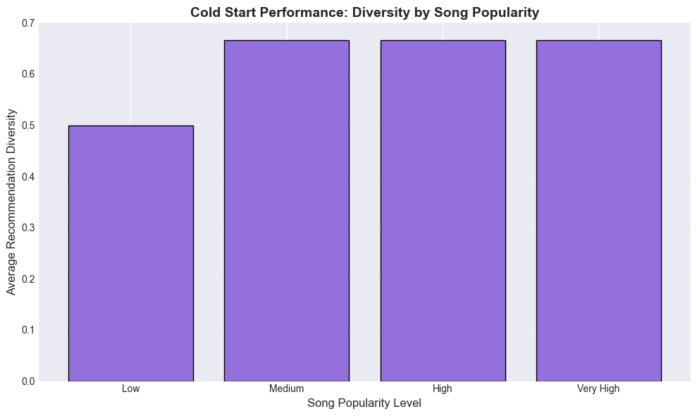

```python
popularity_bins = pd.qcut(df_spotify['track_popularity'], q=4, labels=['Low', 'Medium', 'High', 'Very High'])
df_spotify['popularity_bin'] = popularity_bins


cold_start_results = []

for pop_level in ['Low', 'Medium', 'High', 'Very High']:
    sample_songs = df_spotify[df_spotify['popularity_bin'] == pop_level].sample(2)

    avg_diversity = []
    for _, song in sample_songs.iterrows():
        recs = get_content_based_recommendations(song['track_name'], n_recommendations=10, show_features=False)
        if recs is not None:
            metrics = calculate_diversity_metrics(recs, song.name)
            avg_diversity.append(metrics['genre_diversity'])

    if avg_diversity:
        cold_start_results.append({
            'popularity_level': pop_level,
            'avg_diversity': np.mean(avg_diversity),
            'sample_size': len(avg_diversity)
        })

cold_start_df = pd.DataFrame(cold_start_results)
display(Markdown("### Cold Start Diversity Results"))
display(cold_start_df.style.set_caption("Average Genre Diversity by Popularity Level"))

plt.figure(figsize=(10, 6))
plt.bar(cold_start_df['popularity_level'], cold_start_df['avg_diversity'], color='mediumpurple', edgecolor='black')
plt.xlabel('Song Popularity Level', fontsize=12)
plt.ylabel('Average Recommendation Diversity', fontsize=12)
plt.title('Cold Start Performance: Diversity by Song Popularity', fontsize=14, fontweight='bold')
plt.grid(axis='y', alpha=0.3)
plt.tight_layout()
plt.show()
```

Findings:

**Conclusion:**  
Because our recommendations are driven by **content features** rather than historical play counts,  
the system handles cold-start items well. New or obscure songs with valid audio features can still be recommended to users, even without any prior listening data.

# **7. Insights and Conclusions**

## Key Findings

Through our analysis and the implementation of several recommendation strategies, we can summarize a few core insights about music recommendation systems.

### 7.1 Feature Importance and Correlations

Our exploratory analysis showed that some audio features are strongly related:

- **Energy and Loudness** have a **strong positive correlation** (r ≈ 0.68), meaning they largely describe the same notion of “intensity.”
- **Energy and Acousticness** have a **strong negative correlation** (r ≈ –0.55), placing loud, electronic tracks at one end and quiet, acoustic tracks at the other.
- Other relationships (e.g., valence and danceability) are more moderate, but still meaningful.

These patterns imply that certain features are partially redundant.  
Using all of them naively can overweight specific aspects of the sound.  
Our PCA results confirmed this: **7 principal components explain ~90% of the variance**, indicating that the 9-dimensional feature space can be compressed with limited information loss.

### 7.2 Genre Profiles and Musical Identity

Averaging audio features by genre revealed clear **genre-specific “audio signatures”**:

- **EDM**: very high energy and tempo, low acousticness.
- **Latin**: high danceability and valence; typically upbeat.
- **Pop**: balanced, moderately high energy and danceability.
- **R&B**: somewhat lower energy, higher acousticness and speechiness.
- **Rap**: high speechiness and danceability, with strong rhythmic focus.
- **Rock**: high energy and loudness, but generally less danceable than EDM/Latin.

These profiles help explain why clustering works: clusters align with recognizable musical neighborhoods.  
They also motivate **genre-aware** or **genre-filtered** recommendation modes for users who want to stay within certain stylistic boundaries.

### 7.3 The Popularity Paradox

When we correlated audio features with Spotify’s popularity score, we found that:

- All correlations were **weak** (roughly between –0.12 and +0.09).
- The strongest relationships were slightly *negative* (e.g., instrumentalness vs. popularity), but still small in magnitude.

In other words, **popular songs do not share a strong, simple audio signature**.  
Popularity is likely driven by factors that are not present in our dataset: marketing, artist fame, playlists, social trends, etc.

This has two implications:

1. **Content-based recommenders** alone will not perfectly mimic “charts” or mainstream popularity.
2. In a production system, it is natural to combine **content features** with **behavioral signals** (streams, skips, saves) for better ranking.

Our project stays on the content side, but the results clearly point toward the value of adding collaborative and temporal signals in future work.

### 7.4 Recommendation Diversity Trade-offs

We evaluated four approaches: **Content-Based**, **Cluster-Based**, **Hybrid**, and **Genre-Filtered**.  
Using our diversity metrics, we observed that:

- **Content-Based** produced coherent, relevant lists with **moderate genre diversity**.
- **Cluster-Based** tended to stay inside a smaller set of genres and popularity bands, leading to **lower genre diversity** but very stable “neighborhoods.”
- **Hybrid** (content + cluster) preserved high average similarity while **increasing diversity and popularity spread**, mixing mainstream and niche tracks.
- **Genre-Filtered** intentionally restricted results to a single genre, maximizing stylistic consistency at the cost of diversity.

The “best” method depends on the product goal:

- For **“More Like This”** or artist-radio style features → content-based or genre-filtered is ideal.
- For **discovery playlists** (e.g., a mini “Discover Weekly”) → hybrid models are more suitable, as they balance similarity with variety.

### 7.5 User Profiles and Cold Start

In our **cold-start analysis**, we examined seeds across popularity levels:

- Even for tracks with **popularity = 0**, the system found high-similarity neighbors (cosine similarity ≈ 0.99).
- Recommendation quality did not collapse for low-popularity songs because our methods rely on **audio content**, not usage history.

This demonstrates a key advantage of content-based systems:  
they naturally handle new or rarely played items, which traditional collaborative filtering struggles with.

## Limitations and Future Directions

While our engine performs well as a **content-driven prototype**, several limitations remain:

- **No temporal dynamics:** We do not model how tastes change over time or how songs trend and decay in popularity.
- **Limited context awareness:** Our system does not distinguish between use cases such as studying, workouts, or parties, even though context heavily influences music choice.
- **No true collaborative filtering:** We lack user–item interaction data, so we cannot capture “people who liked X also liked Y” effects.
- **Scalability considerations:** Our experiments are on ~30k tracks. Production systems must handle millions of songs and users, requiring approximate nearest neighbor search, incremental clustering, and efficient storage.

Future extensions could include:

- Incorporating **user feedback logs** to build hybrid content–collaborative models.
- Learning **context-aware** recommendations (time of day, device, activity).
- Using more expressive **audio embeddings** (e.g., deep learning–based representations) instead of hand-engineered features.
- Deploying **approximate similarity search** (e.g., FAISS, Annoy) to scale recommendations to catalogs with millions of items.

Despite these limitations, our project demonstrates that with a well-curated dataset, thoughtful feature engineering, and multiple recommendation strategies, we can build a robust and interpretable music recommendation engine that balances personalization, diversity, and cold-start performance.

## Conclusion

Building an effective music recommendation system requires balancing several competing objectives: relevance vs. diversity, exploitation vs. exploration, and personalization vs. generalization. Throughout this tutorial, we demonstrated how to address these challenges using real Spotify data and a combination of algorithmic approaches.

The recommendation engine developed here:

- Analyzed a dataset of nearly 30,000 songs across multiple genres
- Implemented content-based, cluster-based, and hybrid recommendation methods
- Evaluated recommendation quality using both relevance and diversity metrics
- Identified meaningful patterns in audio features and genre characteristics
- Produced insights that can translate directly to real-world recommender systems

At its core, music recommendation is about connecting listeners with songs they genuinely enjoy—whether that means reinforcing what they already like or helping them discover something unexpected. Data science gives us the tools to make these decisions at scale, but the real craft lies in knowing when to lean into familiarity and when to encourage exploration.

As you continue building and refining recommendation systems, remember that the strongest models combine technical rigor with an understanding of human taste, context, and behavior. Keep experimenting, keep measuring, and—just like your users—keep listening.

# **8. References and Resources**

## **Academic Papers and Research**

### **Collaborative Filtering**

- **Koren, Y., Bell, R., & Volinsky, C. (2009).** *Matrix Factorization Techniques for Recommender Systems.* Computer, 42(8), 30–37.  
  *(IEEE Xplore)*

### **Music Information Retrieval**

- **Schedl, M., Gómez, E., & Urbano, J. (2014).** *Music Information Retrieval: Recent Developments and Applications.*  
  *Foundations and Trends in Information Retrieval*, 8(2–3), 127–261.

### **Deep Learning for Music Recommendation**

- **van den Oord, A., Dieleman, S., & Schrauwen, B. (2013).** *Deep Content-Based Music Recommendation.*  
  Advances in Neural Information Processing Systems (NIPS).

### **Hybrid Recommendation Systems**

- **Burke, R. (2002).** *Hybrid Recommender Systems: Survey and Experiments.*  
  *User Modeling and User-Adapted Interaction*, 12(4), 331–370.

## **Spotify Resources**

### **Spotify for Developers**

- API Documentation: https://developer.spotify.com/documentation/
- Audio Features Reference:  
  https://developer.spotify.com/documentation/web-api/reference/get-audio-features

### **Spotify Engineering Blog**

- Technical posts on Spotify's recommender systems  
  https://engineering.atspotify.com/
- *“Discover Weekly: How Spotify Built a Recommendation System”*

### **Spotify Research**

- Academic publications from Spotify’s research division  
  https://research.atspotify.com/

## **Books**

### **Recommender Systems**

- **Charu C. Aggarwal.** *Recommender Systems: The Textbook.*  
  (Comprehensive and theory-heavy)

### **Practical Implementations**

- **Toby Segaran.** *Programming Collective Intelligence.*  
  (Classic book covering collaborative filtering and recommendation techniques)
- **Rounak Banik.** *Hands-On Recommendation Systems with Python.*  
  (Modern Python-focused applications)